# Projet 6 - Classification Automatique des Biens de Consommation

## Partie 1 de 3

# 1. Introduction

## 1.1 Le Contexte

L’entreprise "Place de marché", qui souhaite lancer une marketplace e-commerce, voudrait mettre en place un moteur de classification: la catégorie d'un article est attribuée automatiquement après le téléchargement d'une photo de l'article. L'entreprise attend que un tel moteur de classification a les bénéfices suivantes :

- augmenter la fiabilité de la classification
- une facilité d'utilisation
  - pour les vendeurs (qui entrent pour l'instant entrent cette info manuellement)
  - pour les achêteurs pour leur recherche de produit

## 1.2 Objectif

- **Etudier la faisabilité d'un moteur de classification**
  - analyse de jeu de données
  - prétraitement des déscriptions (texte) et des images
  - réduction de dimension
  - clustering

## 1.3 Résumé de ce Notebook

Dans ce notebook, on traite le texte de la description du produit en utilisant des librairies NLTK et SpaCy. Le texte est converti en tokens et lemmatisé. Une prémière analyse sur les tokens (les mots dans le texte) et les catégories de produit est faite. Finalement, la description tokenisée et lemmatisée est exportée pour le clustering et une analyse plus poussée.

Conclusions:

- Le jeu de données est complète et équilibré entre les catégories.
- Il y a environ 4600-4800 tokens uniques dont la grande majorité est très infréquent dans le corpus.
- Il y a des tokens qui sont très fréquents et se trouvent dans tous les document -> des stopwords spécifique au corpus
- La lemmatisation n'est pas parfaite - certains mots ne sont pas dans les dictionnaires respectives.

# 2. Les Imports

## 2.1 Les Bibliothèques et Styles

```python
import re, os, random
from math import ceil
# a convenient module for punctuation signs
import string

#data modules
import numpy as np
import pandas as pd
import scipy as sp
from scipy.stats import chisquare


#graphic modules
import matplotlib.pyplot as plt
from matplotlib.image import imread
from matplotlib.colors import ListedColormap


#import matplotlib.dates as dates
import seaborn as sns
```

```python
from collections import defaultdict
from collections import Counter
```

```python
#Text processing module
import spacy

#Image module
import cv2
```

```python
import nltk
nltk.download('wordnet')
nltk.download('omw-1.4')

# stopwords and tokenizer from NLTK
from nltk.corpus import stopwords
from nltk.corpus import wordnet as wn
from nltk.tag import pos_tag, pos_tag_sents

from nltk.tokenize import WordPunctTokenizer
from nltk.stem.wordnet import WordNetLemmatizer
```

```python
%matplotlib inline
```

## 2.2 Les Fonctions - Traitement de Texte

#### Création des Catégories

```python
def decompose_category_tree_to_levels(category_tree, n_levels=1, split_str=' >> ', strip_str='"[]', fillin=False):
    '''Function that decomposes a string representing a category_tree into different levels. \\
    The strings to be stripped off of this string and the strings used to delimit the levels can be entered into \\
    this function : strip_str and split_str
    The output result is a dataframe containing the columns: \\
    the category_tree as a list, the depth of the tree, the levels (upto n_levels or the maximum tree depth).
    The missing category levels further down the tree are filled in with the variable fillin'''
    level_df = pd.DataFrame()
    level_df['category_list'] = category_tree.str.strip(strip_str).str.split(split_str)
    level_df['category_tree_depth'] = level_df['category_list'].apply(len)
    n_levels_max = level_df['category_tree_depth'].max()
    if n_levels_max < n_levels : n_levels = n_levels_max
    if fillin:
        level_df['category_list'] = [fillin_list(ls, n_levels) for ls in level_df['category_list']]
    for n in range(n_levels):
        level_df['category_level'+str(n+1)] = [cat[n] if (n<len(cat)) else np.nan for cat in level_df['category_list']]
    return level_df
```

```python
def fillin_list(ls, ls_length, fillin=None):
    '''Helper function to extend a list 'ls' to length 'ls_length' with the value 'fillin'. '''
    if fillin == None:
        fillin = ls[-1] if len(ls) else np.nan
    return ls + (ls_length - len(ls))*[fillin]
```

#### Prétraitement avec NLTK (Tokenisation, Lemmatisation, etc.)

```python
def tagmap(x):
    '''Returns a default dictionary converting the pos_tag from nltk to wordnet POS tags. '''
    tag_map = defaultdict(lambda : wn.NOUN)
    tag_map['J'] = wn.ADJ
    tag_map['V'] = wn.VERB
    tag_map['R'] = wn.ADV
    x=x[0]
    return tag_map[x]
```

```python
def tokenize_and_lemmatize_with_nltk(txt_srs, stopwords=[]):
    '''Tokenize and Lemmatize a text using NLTK together with wordnet.'''
    tokenizer = WordPunctTokenizer()
    lemmatizer = WordNetLemmatizer()
    txt_df = pd.DataFrame()
    txt_df['tokens_with_pos'] = [txt for txt in txt_srs.apply(lambda x: tokenizer.tokenize(x)).apply(pos_tag)]
    txt_df['lemmas'] = txt_df['tokens_with_pos'].apply(
        lambda x : [lemmatizer.lemmatize(token, tagmap(tag)).lower() for token, tag in x
                    if not ((token.lower() in stopwords) | (lemmatizer.lemmatize(token, tagmap(tag)).lower() in stopwords))])
    txt_df['document'] = txt_df['lemmas'].apply(lambda x : ' '.join(x))
    return txt_df
```

#### Prétraitement avec Spacy (Tokenisation, Lemmatisation, etc.)

```python
def tokenize_and_lemmatize_with_spacy(txt_srs, stopwords=[]):
    '''Tokenize and Lemmatize a text using Spacy.'''
    txt_df = pd.DataFrame()
    txt_df['tokens'] = [list(txt) for txt in txt_srs.apply(lambda x: nlp(x))]
    txt_df['lemmas'] = txt_df['tokens'].apply(lambda x : [str(token.lemma_).lower() for token in x
                                                          if not (token.is_space | token.is_punct | token.is_stop |
                                                          (str(token.lemma_).lower() in stopwords))])
    txt_df['document'] = txt_df['lemmas'].apply(lambda x : ' '.join(x))
    return txt_df
```

```python
def replace_chars_with_space(txt, char_list=[]):
    '''Replace the Characters in char_list with a space.'''
    for char in char_list:
        txt = txt.replace(char, ' ')
    return txt
```

#### Traitement de Document Tokenisé

```python
def token_counter(doc_srs):
    '''Create a Counter object, which counts the occurences of the tokens in a corpus.'''
    all_tokens = ' '.join(doc_srs).split()
    return Counter(all_tokens)
```

```python
def drop_stopwords(doc_srs, stopwords = []):
    '''Function to drop user defined stopwords from a corpus.'''
    doc_df = pd.DataFrame()
    doc_df['document_reduced'] = [[t for t in doc.split() if t not in stopwords] for doc in doc_srs]
    doc_df['document_reduced'] = doc_df['document_reduced'].apply(' '.join)
    return doc_df
```

```python
def unfrequent_tokens(doc_srs, mincount=1):
    '''Function that finds and returns the tokens that occur less than 'mincoutn'-times in the text. '''
    stopwords =[]
    for t in token_counter(doc_srs).most_common()[::-1]:
        if t[1] < mincount :
            stopwords.append(t[0])
        else:
            break
    return stopwords
```

```python
def drop_unfrequent_tokens(doc_srs, mincount=1):
    '''Function that drops tokens with an occurence of less than 'mincount' from the corpus. '''
    stopwords = unfrequent_tokens(doc_srs, mincount)
    doc_df = drop_stopwords(doc_srs, stopwords)
    return doc_df
```

#### Tokens vs. Catégories

```python
def create_observation_matrix(text_df, doc, cat):
    '''Function that counts the occurences of the tokens in a corpus as a function of the document categorie 'cat'. '''
    counter_df = text_df.groupby(by=cat)[doc].apply(
                     ' '.join).apply(lambda x : pd.Series(Counter(x.split()))).fillna(0)
    counter_df = counter_df.join(counter_df.sum(axis=1).rename('TOTAL'))
    counter_df = counter_df.append(counter_df.sum(axis=0).rename('TOTAL'))
    return counter_df
```

```python
def create_expected_observation_matrix(counter_df):
    '''Function that returns the expected token counts per category from an observation matrix if there was no difference
    between the different categories.'''
    name='TOTAL'
    tx = pd.DataFrame(counter_df.iloc[:,-1].rename(name))
    ty = pd.DataFrame(counter_df.iloc[-1,:].rename(name))
    n = counter_df.iloc[-1,-1]
    indep_df = tx.dot(ty.T) / n
    return indep_df
```

```python
def create_chisquared_measure_matrix(counter_df, indep_df):
    '''Function that returns a Chi_Squared matrix given an observation and en expected observation of occurences.'''
    measure_df = (counter_df-indep_df)**2/indep_df
    measure_df.iloc[-1,:] = measure_df.sum(axis=0)
    measure_df.iloc[:,-1] = measure_df.sum(axis=1)
    return measure_df
```

```python
def create_documentfrequency_matrix(text_df, doc, cat):
    '''Function that returns the document frequency of a token as a count.'''
    docfreq_df = text_df[doc].apply(lambda x : pd.Series(Counter(set(x.split())))).fillna(0)
    docfreq_df[cat] = text_df[cat]
    docfreq_df = docfreq_df.groupby(by=cat).sum()
    docfreq_df = docfreq_df.join(docfreq_df.sum(axis=1).rename('TOTAL'))
    docfreq_df = docfreq_df.append(docfreq_df.sum(axis=0).rename('TOTAL'))
    return docfreq_df
```

## 2.3 Les Données

```python
PATH = os.getcwd() + '\\Data\\Flipkart\\'
```

### 2.3.1 Les Déscriptions des Produits

```python
text_df = pd.read_csv(PATH+ 'flipkart_com-ecommerce_sample_1050.csv')
text_df
```

|  | uniq_id | crawl_timestamp | product_url | product_name | product_category_tree | pid | retail_price | discounted_price | image | is_FK_Advantage_product | description | product_rating | overall_rating | brand | product_specifications |
| --- | --- | --- | --- | --- | --- | --- | --- | --- | --- | --- | --- | --- | --- | --- | --- |
| 0 | 55b85ea15a1536d46b7190ad6fff8ce7 | 2016-04-30 03:22:56 +0000 | http://www.flipkart.com/elegance-polyester-mul... | Elegance Polyester Multicolor Abstract Eyelet ... | ["Home Furnishing >> Curtains & Accessories >>... | CRNEG7BKMFFYHQ8Z | 1899.0 | 899.0 | 55b85ea15a1536d46b7190ad6fff8ce7.jpg | False | Key Features of Elegance Polyester Multicolor ... | No rating available | No rating available | Elegance | {"product_specification"=>[{"key"=>"Brand", "v... |
| 1 | 7b72c92c2f6c40268628ec5f14c6d590 | 2016-04-30 03:22:56 +0000 | http://www.flipkart.com/sathiyas-cotton-bath-t... | Sathiyas Cotton Bath Towel | ["Baby Care >> Baby Bath & Skin >> Baby Bath T... | BTWEGFZHGBXPHZUH | 600.0 | 449.0 | 7b72c92c2f6c40268628ec5f14c6d590.jpg | False | Specifications of Sathiyas Cotton Bath Towel (... | No rating available | No rating available | Sathiyas | {"product_specification"=>[{"key"=>"Machine Wa... |
| 2 | 64d5d4a258243731dc7bbb1eef49ad74 | 2016-04-30 03:22:56 +0000 | http://www.flipkart.com/eurospa-cotton-terry-f... | Eurospa Cotton Terry Face Towel Set | ["Baby Care >> Baby Bath & Skin >> Baby Bath T... | BTWEG6SHXTDB2A2Y | NaN | NaN | 64d5d4a258243731dc7bbb1eef49ad74.jpg | False | Key Features of Eurospa Cotton Terry Face Towe... | No rating available | No rating available | Eurospa | {"product_specification"=>[{"key"=>"Material",... |
| 3 | d4684dcdc759dd9cdf41504698d737d8 | 2016-06-20 08:49:52 +0000 | http://www.flipkart.com/santosh-royal-fashion-... | SANTOSH ROYAL FASHION Cotton Printed King size... | ["Home Furnishing >> Bed Linen >> Bedsheets >>... | BDSEJT9UQWHDUBH4 | 2699.0 | 1299.0 | d4684dcdc759dd9cdf41504698d737d8.jpg | False | Key Features of SANTOSH ROYAL FASHION Cotton P... | No rating available | No rating available | SANTOSH ROYAL FASHION | {"product_specification"=>[{"key"=>"Brand", "v... |
| 4 | 6325b6870c54cd47be6ebfbffa620ec7 | 2016-06-20 08:49:52 +0000 | http://www.flipkart.com/jaipur-print-cotton-fl... | Jaipur Print Cotton Floral King sized Double B... | ["Home Furnishing >> Bed Linen >> Bedsheets >>... | BDSEJTHNGWVGWWQU | 2599.0 | 698.0 | 6325b6870c54cd47be6ebfbffa620ec7.jpg | False | Key Features of Jaipur Print Cotton Floral Kin... | No rating available | No rating available | Jaipur Print | {"product_specification"=>[{"key"=>"Machine Wa... |
| ... | ... | ... | ... | ... | ... | ... | ... | ... | ... | ... | ... | ... | ... | ... | ... |
| 1045 | 958f54f4c46b53c8a0a9b8167d9140bc | 2015-12-01 10:15:43 +0000 | http://www.flipkart.com/oren-empower-extra-lar... | Oren Empower Extra Large Self Adhesive Sticker | ["Baby Care >> Baby & Kids Gifts >> Stickers >... | STIE88ZGTX65GH4V | 1399.0 | 999.0 | 958f54f4c46b53c8a0a9b8167d9140bc.jpg | False | Oren Empower Extra Large Self Adhesive Sticker... | No rating available | No rating available | Oren Empower | {"product_specification"=>[{"key"=>"Number of ... |
| 1046 | fd6cbcc22efb6b761bd564c28928483c | 2015-12-01 10:15:43 +0000 | http://www.flipkart.com/wallmantra-large-vinyl... | Wallmantra Large Vinyl Sticker Sticker | ["Baby Care >> Baby & Kids Gifts >> Stickers >... | STIEC889ZD5GDCVQ | 4930.0 | 1896.0 | fd6cbcc22efb6b761bd564c28928483c.jpg | False | Wallmantra Large Vinyl Sticker Sticker (Pack o... | No rating available | No rating available | Wallmantra | {"product_specification"=>[{"key"=>"Number of ... |
| 1047 | 5912e037d12774bb73a2048f35a00009 | 2015-12-01 10:15:43 +0000 | http://www.flipkart.com/uberlyfe-extra-large-p... | Uberlyfe Extra Large Pigmented Polyvinyl Films... | ["Baby Care >> Baby & Kids Gifts >> Stickers >... | STIE5UVGW2JWVWCT | 4500.0 | 1449.0 | 5912e037d12774bb73a2048f35a00009.jpg | False | Buy Uberlyfe Extra Large Pigmented Polyvinyl F... | No rating available | No rating available | Uberlyfe | {"product_specification"=>[{"key"=>"Number of ... |
| 1048 | c3edc504d1b4f0ba6224fa53a43a7ad6 | 2015-12-01 10:15:43 +0000 | http://www.flipkart.com/wallmantra-medium-viny... | Wallmantra Medium Vinyl Sticker Sticker | ["Baby Care >> Baby & Kids Gifts >> Stickers >... | STIEC889ZGFD3RCE | 3465.0 | 1333.0 | c3edc504d1b4f0ba6224fa53a43a7ad6.jpg | False | Buy Wallmantra Medium Vinyl Sticker Sticker fo... | No rating available | No rating available | Wallmantra | {"product_specification"=>[{"key"=>"Number of ... |
| 1049 | f2f027ad6a6df617c9f125173da71e44 | 2015-12-01 10:15:43 +0000 | http://www.flipkart.com/uberlyfe-large-vinyl-s... | Uberlyfe Large Vinyl Sticker | ["Baby Care >> Baby & Kids Gifts >> Stickers >... | STIE2ZEPACRQJKH7 | 1190.0 | 595.0 | f2f027ad6a6df617c9f125173da71e44.jpg | False | Buy Uberlyfe Large Vinyl Sticker for Rs.595 on... | 4 | 4 | Uberlyfe | {"product_specification"=>[{"key"=>"Sales Pack... |

1050 rows × 15 columns

```python
text_df = text_df.drop(columns = ['crawl_timestamp', 'product_url', 'pid', 'retail_price', 'discounted_price',
                                  'is_FK_Advantage_product', 'product_rating', 'overall_rating'])
text_df = text_df.rename(columns = {'uniq_id':'image_id','image':'image_file'})
text_df
```

|  | image_id | product_name | product_category_tree | image_file | description | brand | product_specifications |
| --- | --- | --- | --- | --- | --- | --- | --- |
| 0 | 55b85ea15a1536d46b7190ad6fff8ce7 | Elegance Polyester Multicolor Abstract Eyelet ... | ["Home Furnishing >> Curtains & Accessories >>... | 55b85ea15a1536d46b7190ad6fff8ce7.jpg | Key Features of Elegance Polyester Multicolor ... | Elegance | {"product_specification"=>[{"key"=>"Brand", "v... |
| 1 | 7b72c92c2f6c40268628ec5f14c6d590 | Sathiyas Cotton Bath Towel | ["Baby Care >> Baby Bath & Skin >> Baby Bath T... | 7b72c92c2f6c40268628ec5f14c6d590.jpg | Specifications of Sathiyas Cotton Bath Towel (... | Sathiyas | {"product_specification"=>[{"key"=>"Machine Wa... |
| 2 | 64d5d4a258243731dc7bbb1eef49ad74 | Eurospa Cotton Terry Face Towel Set | ["Baby Care >> Baby Bath & Skin >> Baby Bath T... | 64d5d4a258243731dc7bbb1eef49ad74.jpg | Key Features of Eurospa Cotton Terry Face Towe... | Eurospa | {"product_specification"=>[{"key"=>"Material",... |
| 3 | d4684dcdc759dd9cdf41504698d737d8 | SANTOSH ROYAL FASHION Cotton Printed King size... | ["Home Furnishing >> Bed Linen >> Bedsheets >>... | d4684dcdc759dd9cdf41504698d737d8.jpg | Key Features of SANTOSH ROYAL FASHION Cotton P... | SANTOSH ROYAL FASHION | {"product_specification"=>[{"key"=>"Brand", "v... |
| 4 | 6325b6870c54cd47be6ebfbffa620ec7 | Jaipur Print Cotton Floral King sized Double B... | ["Home Furnishing >> Bed Linen >> Bedsheets >>... | 6325b6870c54cd47be6ebfbffa620ec7.jpg | Key Features of Jaipur Print Cotton Floral Kin... | Jaipur Print | {"product_specification"=>[{"key"=>"Machine Wa... |
| ... | ... | ... | ... | ... | ... | ... | ... |
| 1045 | 958f54f4c46b53c8a0a9b8167d9140bc | Oren Empower Extra Large Self Adhesive Sticker | ["Baby Care >> Baby & Kids Gifts >> Stickers >... | 958f54f4c46b53c8a0a9b8167d9140bc.jpg | Oren Empower Extra Large Self Adhesive Sticker... | Oren Empower | {"product_specification"=>[{"key"=>"Number of ... |
| 1046 | fd6cbcc22efb6b761bd564c28928483c | Wallmantra Large Vinyl Sticker Sticker | ["Baby Care >> Baby & Kids Gifts >> Stickers >... | fd6cbcc22efb6b761bd564c28928483c.jpg | Wallmantra Large Vinyl Sticker Sticker (Pack o... | Wallmantra | {"product_specification"=>[{"key"=>"Number of ... |
| 1047 | 5912e037d12774bb73a2048f35a00009 | Uberlyfe Extra Large Pigmented Polyvinyl Films... | ["Baby Care >> Baby & Kids Gifts >> Stickers >... | 5912e037d12774bb73a2048f35a00009.jpg | Buy Uberlyfe Extra Large Pigmented Polyvinyl F... | Uberlyfe | {"product_specification"=>[{"key"=>"Number of ... |
| 1048 | c3edc504d1b4f0ba6224fa53a43a7ad6 | Wallmantra Medium Vinyl Sticker Sticker | ["Baby Care >> Baby & Kids Gifts >> Stickers >... | c3edc504d1b4f0ba6224fa53a43a7ad6.jpg | Buy Wallmantra Medium Vinyl Sticker Sticker fo... | Wallmantra | {"product_specification"=>[{"key"=>"Number of ... |
| 1049 | f2f027ad6a6df617c9f125173da71e44 | Uberlyfe Large Vinyl Sticker | ["Baby Care >> Baby & Kids Gifts >> Stickers >... | f2f027ad6a6df617c9f125173da71e44.jpg | Buy Uberlyfe Large Vinyl Sticker for Rs.595 on... | Uberlyfe | {"product_specification"=>[{"key"=>"Sales Pack... |

1050 rows × 7 columns

```python
#check that the image ids and files correspond
(text_df['image_id'] != [t.removesuffix('.jpg') for t in text_df['image_file']]).sum()
```

```
0
```

### 2.3.2 Les Photos des Produits

```python
photo_list = [file for file in os.listdir(PATH + "Images\\")]
print(f"Il y a {len(photo_list)} photo dans le dataset.")
```

```
Il y a 1050 photo dans le dataset.
```

```python
photos_df = pd.DataFrame()
photos_df["image_file"] = photo_list
photos_df["image_id"] = [file.removesuffix('.jpg') for file in photo_list]
photos_df
```

|  | image_file | image_id |
| --- | --- | --- |
| 0 | 009099b1f6e1e8f893ec29a7023153c4.jpg | 009099b1f6e1e8f893ec29a7023153c4 |
| 1 | 0096e89cc25a8b96fb9808716406fe94.jpg | 0096e89cc25a8b96fb9808716406fe94 |
| 2 | 00cbbc837d340fa163d11e169fbdb952.jpg | 00cbbc837d340fa163d11e169fbdb952 |
| 3 | 00d84a518e0550612fcfcba3b02b6255.jpg | 00d84a518e0550612fcfcba3b02b6255 |
| 4 | 00e966a5049a262cfc72e6bbf68b80e7.jpg | 00e966a5049a262cfc72e6bbf68b80e7 |
| ... | ... | ... |
| 1045 | feefbdff924dd6b7cc266449c9a36d69.jpg | feefbdff924dd6b7cc266449c9a36d69 |
| 1046 | ff24511994fc459d04145231c8876d6c.jpg | ff24511994fc459d04145231c8876d6c |
| 1047 | ffbf3794aa8cb6bb8d3f313d0a549a09.jpg | ffbf3794aa8cb6bb8d3f313d0a549a09 |
| 1048 | ffc2e1fc7c886ec09a331040ada038aa.jpg | ffc2e1fc7c886ec09a331040ada038aa |
| 1049 | fffa2117a4006d4a848eb7d5b80d4816.jpg | fffa2117a4006d4a848eb7d5b80d4816 |

1050 rows × 2 columns

[figure not shown]

```python
#show three random images
plt.subplots(1,3, figsize=(16,4))
for i, name in enumerate(random.sample(photo_list, k=3)) :
    filename = PATH + "Images\\" + name
    image = imread(filename)
    plt.subplot(131+i)
    plt.imshow(image)
plt.show()
```

```
['Buy My Party Suppliers 720 inch Multicolor Rice Lights for Rs.850 online. My Party Suppliers 720 inch Multicolor Rice Lights at best prices with FREE shipping & cash on delivery. Only Genuine Products. 30 Day Replacement Guarantee.']
```

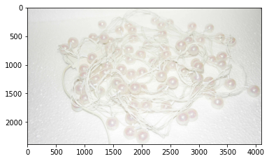

```python
for name in random.sample(photo_list, k=1) :
    print(text_df[text_df["image_file"]==name]["description"].values)
    filename = PATH + "Images\\" + name
    image = imread(filename)
    plt.imshow(image)
plt.show()
```

```python
#check that the image ids for the text and the photos correspond
set(photos_df['image_id'].values) - set(text_df['image_id'].values)
```

```
set()
```

# 3. Le Texte

## 3.1 La Catégorisation

```python
decompose_category_tree_to_levels(text_df['product_category_tree'], 5, fillin=False).describe(include='all')
```

|  | category_list | category_tree_depth | category_level1 | category_level2 | category_level3 | category_level4 | category_level5 |
| --- | --- | --- | --- | --- | --- | --- | --- |
| count | 1050 | 1050.000000 | 1050 | 1050 | 1047 | 679 | 405 |
| unique | 642 | NaN | 7 | 62 | 241 | 349 | 297 |
| top | [Home Furnishing, Bed Linen, Blankets, Quilts ... | NaN | Home Furnishing | Wrist Watches | Deodorants | Combos | Dresses |
| freq | 56 | NaN | 150 | 149 | 65 | 64 | 21 |
| mean | NaN | 4.204762 | NaN | NaN | NaN | NaN | NaN |
| std | NaN | 1.158126 | NaN | NaN | NaN | NaN | NaN |
| min | NaN | 2.000000 | NaN | NaN | NaN | NaN | NaN |
| 25% | NaN | 3.000000 | NaN | NaN | NaN | NaN | NaN |
| 50% | NaN | 4.000000 | NaN | NaN | NaN | NaN | NaN |
| 75% | NaN | 5.000000 | NaN | NaN | NaN | NaN | NaN |
| max | NaN | 7.000000 | NaN | NaN | NaN | NaN | NaN |

```python
decompose_category_tree_to_levels(text_df['product_category_tree'], 1)[['category_level1']].value_counts(sort=False)
```

```
category_level1
Baby Care                     150
Beauty and Personal Care      150
Computers                     150
Home Decor & Festive Needs    150
Home Furnishing               150
Kitchen & Dining              150
Watches                       150
dtype: int64
```

```python
decompose_category_tree_to_levels(text_df['product_category_tree'], 2)[['category_level1','category_level2']].value_counts(sort=False)[2:]
```

```
category_level1             category_level2
Baby Care                   Baby Bedding                        15
                            Baby Grooming                        4
                            Diapering & Potty Training           7
                            Feeding & Nursing                    8
                            Furniture & Furnishings              2
                            Infant Wear                         84
                            Strollers & Activity Gear            1
Beauty and Personal Care    Bath and Spa                         7
                            Beauty Accessories                   1
                            Body and Skin Care                  15
                            Combos and Kits                     24
                            Eye Care                             2
                            Fragrances                          65
                            Hair Care                            9
                            Health Care                          7
                            Makeup                              18
                            Men's Grooming                       1
                            Women's Hygiene                      1
Computers                   Computer Components                  2
                            Computer Peripherals                 4
                            Laptop Accessories                  87
                            Laptops                              2
                            Network Components                  49
                            Software                             1
                            Storage                              2
                            Tablet Accessories                   3
Home Decor & Festive Needs  Candles & Fragrances                 1
                            Decorative Lighting & Lamps         14
                            Flowers, Plants & Vases              5
                            Garden & Leisure                     1
                            Religion & Devotion                  3
                            Showpiece                            5
                            Showpieces                          71
                            TRUE Home Decor & Festive Needs      1
                            Table Decor & Handicrafts           27
                            Wall Decor & Clocks                 22
Home Furnishing             Bath Linen                          21
                            Bed Linen                           65
                            Curtains & Accessories              19
                            Cushions, Pillows & Covers          13
                            Floor Coverings                      6
                            JMD Home Furnishing                  1
                            Kitchen & Dining Linen              14
                            Kripa's Home Furnishing              1
                            Living                               6
                            Living Room Furnishing               3
                            Tidy Home Furnishing                 1
Kitchen & Dining            Bar & Glassware                      8
                            Coffee Mugs                         74
                            Consumables & Disposables            1
                            Containers & Bottles                13
                            Cookware                            27
                            Dinnerware & Crockery                1
                            Housekeeping & Laundry               1
                            Kitchen Tools                       14
                            Lighting                             7
                            Pressure Cookers & Pans              1
                            Tableware & Cutlery                  3
Watches                     Clocks                               1
                            Wrist Watches                      149
dtype: int64
```

```python
text_df = text_df.merge(decompose_category_tree_to_levels(text_df['product_category_tree'], 5),
                        left_index = True, right_index = True)
```

## 3.2 La Tokenisation de la Description

```python
text_df['description'].apply(len).describe()
```

```
count    1050.000000
mean      473.820952
std       457.910422
min       109.000000
25%       192.000000
50%       278.000000
75%       588.250000
max      3490.000000
Name: description, dtype: float64
```

### 3.2.1 Tokenisation et Lemmatisation avec NLTK and Wordnet

```python
punctuation_signs = [s for s in string.punctuation] + ['–','?','.','’']
nltk_stopwords = stopwords.words("english")
all_my_stopwords = punctuation_signs + nltk_stopwords
```

```python
all_my_stopwords
```

```
['!',
 '"',
 '#',
 '$',
 '%',
 '&',
 "'",
 '(',
 ')',
 '*',
 '+',
 ',',
 '-',
 '.',
 '/',
 ':',
 ';',
 '<',
 '=',
 '>',
 '?',
 '@',
 '[',
 '\\',
 ']',
 '^',
 '_',
 '`',
 '{',
 '|',
 '}',
 '~',
 '–',
 '?',
 '.',
 '’',
 'i',
 'me',
 'my',
 'myself',
```

[output cut: 160 more lines]

```
 "mustn't",
 'needn',
 "needn't",
 'shan',
 "shan't",
 'shouldn',
 "shouldn't",
 'wasn',
 "wasn't",
 'weren',
 "weren't",
 'won',
 "won't",
 'wouldn',
 "wouldn't"]
```

```python
text_df = text_df.merge(tokenize_and_lemmatize_with_nltk(text_df['description'], stopwords = all_my_stopwords),
                        left_index=True, right_index=True)
```

```python
text_df
```

|  | image_id | product_name | product_category_tree | image_file | description | brand | product_specifications | category_list | category_tree_depth | category_level1 | category_level2 | category_level3 | category_level4 | category_level5 | tokens_with_pos | lemmas | document |
| --- | --- | --- | --- | --- | --- | --- | --- | --- | --- | --- | --- | --- | --- | --- | --- | --- | --- |
| 0 | 55b85ea15a1536d46b7190ad6fff8ce7 | Elegance Polyester Multicolor Abstract Eyelet ... | ["Home Furnishing >> Curtains & Accessories >>... | 55b85ea15a1536d46b7190ad6fff8ce7.jpg | Key Features of Elegance Polyester Multicolor ... | Elegance | {"product_specification"=>[{"key"=>"Brand", "v... | [Home Furnishing, Curtains & Accessories, Curt... | 4 | Home Furnishing | Curtains & Accessories | Curtains | Elegance Polyester Multicolor Abstract Eyelet ... | NaN | [(Key, NNP), (Features, NNP), (of, IN), (Elega... | [key, features, elegance, polyester, multicolo... | key features elegance polyester multicolor abs... |
| 1 | 7b72c92c2f6c40268628ec5f14c6d590 | Sathiyas Cotton Bath Towel | ["Baby Care >> Baby Bath & Skin >> Baby Bath T... | 7b72c92c2f6c40268628ec5f14c6d590.jpg | Specifications of Sathiyas Cotton Bath Towel (... | Sathiyas | {"product_specification"=>[{"key"=>"Machine Wa... | [Baby Care, Baby Bath & Skin, Baby Bath Towels... | 5 | Baby Care | Baby Bath & Skin | Baby Bath Towels | Sathiyas Baby Bath Towels | Sathiyas Cotton Bath Towel (3 Bath Towel, Red,... | [(Specifications, NNS), (of, IN), (Sathiyas, N... | [specifications, sathiyas, cotton, bath, towel... | specifications sathiyas cotton bath towel 3 ba... |
| 2 | 64d5d4a258243731dc7bbb1eef49ad74 | Eurospa Cotton Terry Face Towel Set | ["Baby Care >> Baby Bath & Skin >> Baby Bath T... | 64d5d4a258243731dc7bbb1eef49ad74.jpg | Key Features of Eurospa Cotton Terry Face Towe... | Eurospa | {"product_specification"=>[{"key"=>"Material",... | [Baby Care, Baby Bath & Skin, Baby Bath Towels... | 5 | Baby Care | Baby Bath & Skin | Baby Bath Towels | Eurospa Baby Bath Towels | Eurospa Cotton Terry Face Towel Set (20 PIECE ... | [(Key, NNP), (Features, NNP), (of, IN), (Euros... | [key, features, eurospa, cotton, terry, face, ... | key features eurospa cotton terry face towel s... |
| 3 | d4684dcdc759dd9cdf41504698d737d8 | SANTOSH ROYAL FASHION Cotton Printed King size... | ["Home Furnishing >> Bed Linen >> Bedsheets >>... | d4684dcdc759dd9cdf41504698d737d8.jpg | Key Features of SANTOSH ROYAL FASHION Cotton P... | SANTOSH ROYAL FASHION | {"product_specification"=>[{"key"=>"Brand", "v... | [Home Furnishing, Bed Linen, Bedsheets, SANTOS... | 5 | Home Furnishing | Bed Linen | Bedsheets | SANTOSH ROYAL FASHION Bedsheets | SANTOSH ROYAL FASHION Cotton Printed King size... | [(Key, NNP), (Features, NNP), (of, IN), (SANTO... | [key, features, santosh, royal, fashion, cotto... | key features santosh royal fashion cotton prin... |
| 4 | 6325b6870c54cd47be6ebfbffa620ec7 | Jaipur Print Cotton Floral King sized Double B... | ["Home Furnishing >> Bed Linen >> Bedsheets >>... | 6325b6870c54cd47be6ebfbffa620ec7.jpg | Key Features of Jaipur Print Cotton Floral Kin... | Jaipur Print | {"product_specification"=>[{"key"=>"Machine Wa... | [Home Furnishing, Bed Linen, Bedsheets, Jaipur... | 5 | Home Furnishing | Bed Linen | Bedsheets | Jaipur Print Bedsheets | Jaipur Print Cotton Floral King sized Double B... | [(Key, NNP), (Features, NNP), (of, IN), (Jaipu... | [key, features, jaipur, print, cotton, floral,... | key features jaipur print cotton floral king s... |
| ... | ... | ... | ... | ... | ... | ... | ... | ... | ... | ... | ... | ... | ... | ... | ... | ... | ... |
| 1045 | 958f54f4c46b53c8a0a9b8167d9140bc | Oren Empower Extra Large Self Adhesive Sticker | ["Baby Care >> Baby & Kids Gifts >> Stickers >... | 958f54f4c46b53c8a0a9b8167d9140bc.jpg | Oren Empower Extra Large Self Adhesive Sticker... | Oren Empower | {"product_specification"=>[{"key"=>"Number of ... | [Baby Care, Baby & Kids Gifts, Stickers, Oren ... | 4 | Baby Care | Baby & Kids Gifts | Stickers | Oren Empower Stickers | NaN | [(Oren, NNP), (Empower, NNP), (Extra, NNP), (L... | [oren, empower, extra, large, self, adhesive, ... | oren empower extra large self adhesive sticker... |
| 1046 | fd6cbcc22efb6b761bd564c28928483c | Wallmantra Large Vinyl Sticker Sticker | ["Baby Care >> Baby & Kids Gifts >> Stickers >... | fd6cbcc22efb6b761bd564c28928483c.jpg | Wallmantra Large Vinyl Sticker Sticker (Pack o... | Wallmantra | {"product_specification"=>[{"key"=>"Number of ... | [Baby Care, Baby & Kids Gifts, Stickers, Wallm... | 4 | Baby Care | Baby & Kids Gifts | Stickers | Wallmantra Stickers | NaN | [(Wallmantra, NNP), (Large, NNP), (Vinyl, NNP)... | [wallmantra, large, vinyl, sticker, sticker, p... | wallmantra large vinyl sticker sticker pack 1 ... |
| 1047 | 5912e037d12774bb73a2048f35a00009 | Uberlyfe Extra Large Pigmented Polyvinyl Films... | ["Baby Care >> Baby & Kids Gifts >> Stickers >... | 5912e037d12774bb73a2048f35a00009.jpg | Buy Uberlyfe Extra Large Pigmented Polyvinyl F... | Uberlyfe | {"product_specification"=>[{"key"=>"Number of ... | [Baby Care, Baby & Kids Gifts, Stickers, Uberl... | 4 | Baby Care | Baby & Kids Gifts | Stickers | Uberlyfe Stickers | NaN | [(Buy, NNP), (Uberlyfe, NNP), (Extra, NNP), (L... | [buy, uberlyfe, extra, large, pigmented, polyv... | buy uberlyfe extra large pigmented polyvinyl f... |
| 1048 | c3edc504d1b4f0ba6224fa53a43a7ad6 | Wallmantra Medium Vinyl Sticker Sticker | ["Baby Care >> Baby & Kids Gifts >> Stickers >... | c3edc504d1b4f0ba6224fa53a43a7ad6.jpg | Buy Wallmantra Medium Vinyl Sticker Sticker fo... | Wallmantra | {"product_specification"=>[{"key"=>"Number of ... | [Baby Care, Baby & Kids Gifts, Stickers, Wallm... | 4 | Baby Care | Baby & Kids Gifts | Stickers | Wallmantra Stickers | NaN | [(Buy, NNP), (Wallmantra, NNP), (Medium, NNP),... | [buy, wallmantra, medium, vinyl, sticker, stic... | buy wallmantra medium vinyl sticker sticker rs... |
| 1049 | f2f027ad6a6df617c9f125173da71e44 | Uberlyfe Large Vinyl Sticker | ["Baby Care >> Baby & Kids Gifts >> Stickers >... | f2f027ad6a6df617c9f125173da71e44.jpg | Buy Uberlyfe Large Vinyl Sticker for Rs.595 on... | Uberlyfe | {"product_specification"=>[{"key"=>"Sales Pack... | [Baby Care, Baby & Kids Gifts, Stickers, Uberl... | 4 | Baby Care | Baby & Kids Gifts | Stickers | Uberlyfe Stickers | NaN | [(Buy, NNP), (Uberlyfe, NNP), (Large, NNP), (V... | [buy, uberlyfe, large, vinyl, sticker, rs, 595... | buy uberlyfe large vinyl sticker rs 595 online... |

1050 rows × 17 columns

```python
text_df = text_df.rename(columns = {'tokens_with_pos' : 'tokens_with_pos_nltk',
                                    'lemmas' : 'lemmas_nltk',
                                    'document' : 'document_nltk'})
```

### 3.2.2 Tokenisation et Lemmatisation avex SpaCy

```python
nlp = spacy.load("en_core_web_sm")
nlp.Defaults.stop_words.add('\r\n')
nlp.Defaults.stop_words.add('\r\n\r\n')
```

```python
text_df = text_df.merge(tokenize_and_lemmatize_with_spacy(text_df['description'], stopwords = all_my_stopwords),
                        left_index=True, right_index=True)
```

```python
text_df
```

|  | image_id | product_name | product_category_tree | image_file | description | brand | product_specifications | category_list | category_tree_depth | category_level1 | category_level2 | category_level3 | category_level4 | category_level5 | tokens_with_pos_nltk | lemmas_nltk | document_nltk | tokens | lemmas | document |
| --- | --- | --- | --- | --- | --- | --- | --- | --- | --- | --- | --- | --- | --- | --- | --- | --- | --- | --- | --- | --- |
| 0 | 55b85ea15a1536d46b7190ad6fff8ce7 | Elegance Polyester Multicolor Abstract Eyelet ... | ["Home Furnishing >> Curtains & Accessories >>... | 55b85ea15a1536d46b7190ad6fff8ce7.jpg | Key Features of Elegance Polyester Multicolor ... | Elegance | {"product_specification"=>[{"key"=>"Brand", "v... | [Home Furnishing, Curtains & Accessories, Curt... | 4 | Home Furnishing | Curtains & Accessories | Curtains | Elegance Polyester Multicolor Abstract Eyelet ... | NaN | [(Key, NNP), (Features, NNP), (of, IN), (Elega... | [key, features, elegance, polyester, multicolo... | key features elegance polyester multicolor abs... | [Key, Features, of, Elegance, Polyester, Multi... | [key, features, elegance, polyester, multicolo... | key features elegance polyester multicolor abs... |
| 1 | 7b72c92c2f6c40268628ec5f14c6d590 | Sathiyas Cotton Bath Towel | ["Baby Care >> Baby Bath & Skin >> Baby Bath T... | 7b72c92c2f6c40268628ec5f14c6d590.jpg | Specifications of Sathiyas Cotton Bath Towel (... | Sathiyas | {"product_specification"=>[{"key"=>"Machine Wa... | [Baby Care, Baby Bath & Skin, Baby Bath Towels... | 5 | Baby Care | Baby Bath & Skin | Baby Bath Towels | Sathiyas Baby Bath Towels | Sathiyas Cotton Bath Towel (3 Bath Towel, Red,... | [(Specifications, NNS), (of, IN), (Sathiyas, N... | [specifications, sathiyas, cotton, bath, towel... | specifications sathiyas cotton bath towel 3 ba... | [Specifications, of, Sathiyas, Cotton, Bath, T... | [specification, sathiyas, cotton, bath, towel,... | specification sathiyas cotton bath towel 3 bat... |
| 2 | 64d5d4a258243731dc7bbb1eef49ad74 | Eurospa Cotton Terry Face Towel Set | ["Baby Care >> Baby Bath & Skin >> Baby Bath T... | 64d5d4a258243731dc7bbb1eef49ad74.jpg | Key Features of Eurospa Cotton Terry Face Towe... | Eurospa | {"product_specification"=>[{"key"=>"Material",... | [Baby Care, Baby Bath & Skin, Baby Bath Towels... | 5 | Baby Care | Baby Bath & Skin | Baby Bath Towels | Eurospa Baby Bath Towels | Eurospa Cotton Terry Face Towel Set (20 PIECE ... | [(Key, NNP), (Features, NNP), (of, IN), (Euros... | [key, features, eurospa, cotton, terry, face, ... | key features eurospa cotton terry face towel s... | [Key, Features, of, Eurospa, Cotton, Terry, Fa... | [key, features, eurospa, cotton, terry, face, ... | key features eurospa cotton terry face towel s... |
| 3 | d4684dcdc759dd9cdf41504698d737d8 | SANTOSH ROYAL FASHION Cotton Printed King size... | ["Home Furnishing >> Bed Linen >> Bedsheets >>... | d4684dcdc759dd9cdf41504698d737d8.jpg | Key Features of SANTOSH ROYAL FASHION Cotton P... | SANTOSH ROYAL FASHION | {"product_specification"=>[{"key"=>"Brand", "v... | [Home Furnishing, Bed Linen, Bedsheets, SANTOS... | 5 | Home Furnishing | Bed Linen | Bedsheets | SANTOSH ROYAL FASHION Bedsheets | SANTOSH ROYAL FASHION Cotton Printed King size... | [(Key, NNP), (Features, NNP), (of, IN), (SANTO... | [key, features, santosh, royal, fashion, cotto... | key features santosh royal fashion cotton prin... | [Key, Features, of, SANTOSH, ROYAL, FASHION, C... | [key, features, santosh, royal, fashion, cotto... | key features santosh royal fashion cotton prin... |
| 4 | 6325b6870c54cd47be6ebfbffa620ec7 | Jaipur Print Cotton Floral King sized Double B... | ["Home Furnishing >> Bed Linen >> Bedsheets >>... | 6325b6870c54cd47be6ebfbffa620ec7.jpg | Key Features of Jaipur Print Cotton Floral Kin... | Jaipur Print | {"product_specification"=>[{"key"=>"Machine Wa... | [Home Furnishing, Bed Linen, Bedsheets, Jaipur... | 5 | Home Furnishing | Bed Linen | Bedsheets | Jaipur Print Bedsheets | Jaipur Print Cotton Floral King sized Double B... | [(Key, NNP), (Features, NNP), (of, IN), (Jaipu... | [key, features, jaipur, print, cotton, floral,... | key features jaipur print cotton floral king s... | [Key, Features, of, Jaipur, Print, Cotton, Flo... | [key, features, jaipur, print, cotton, floral,... | key features jaipur print cotton floral king s... |
| ... | ... | ... | ... | ... | ... | ... | ... | ... | ... | ... | ... | ... | ... | ... | ... | ... | ... | ... | ... | ... |
| 1045 | 958f54f4c46b53c8a0a9b8167d9140bc | Oren Empower Extra Large Self Adhesive Sticker | ["Baby Care >> Baby & Kids Gifts >> Stickers >... | 958f54f4c46b53c8a0a9b8167d9140bc.jpg | Oren Empower Extra Large Self Adhesive Sticker... | Oren Empower | {"product_specification"=>[{"key"=>"Number of ... | [Baby Care, Baby & Kids Gifts, Stickers, Oren ... | 4 | Baby Care | Baby & Kids Gifts | Stickers | Oren Empower Stickers | NaN | [(Oren, NNP), (Empower, NNP), (Extra, NNP), (L... | [oren, empower, extra, large, self, adhesive, ... | oren empower extra large self adhesive sticker... | [Oren, Empower, Extra, Large, Self, Adhesive, ... | [oren, empower, extra, large, self, adhesive, ... | oren empower extra large self adhesive sticker... |
| 1046 | fd6cbcc22efb6b761bd564c28928483c | Wallmantra Large Vinyl Sticker Sticker | ["Baby Care >> Baby & Kids Gifts >> Stickers >... | fd6cbcc22efb6b761bd564c28928483c.jpg | Wallmantra Large Vinyl Sticker Sticker (Pack o... | Wallmantra | {"product_specification"=>[{"key"=>"Number of ... | [Baby Care, Baby & Kids Gifts, Stickers, Wallm... | 4 | Baby Care | Baby & Kids Gifts | Stickers | Wallmantra Stickers | NaN | [(Wallmantra, NNP), (Large, NNP), (Vinyl, NNP)... | [wallmantra, large, vinyl, sticker, sticker, p... | wallmantra large vinyl sticker sticker pack 1 ... | [Wallmantra, Large, Vinyl, Sticker, Sticker, (... | [wallmantra, large, vinyl, sticker, sticker, p... | wallmantra large vinyl sticker sticker pack 1 ... |
| 1047 | 5912e037d12774bb73a2048f35a00009 | Uberlyfe Extra Large Pigmented Polyvinyl Films... | ["Baby Care >> Baby & Kids Gifts >> Stickers >... | 5912e037d12774bb73a2048f35a00009.jpg | Buy Uberlyfe Extra Large Pigmented Polyvinyl F... | Uberlyfe | {"product_specification"=>[{"key"=>"Number of ... | [Baby Care, Baby & Kids Gifts, Stickers, Uberl... | 4 | Baby Care | Baby & Kids Gifts | Stickers | Uberlyfe Stickers | NaN | [(Buy, NNP), (Uberlyfe, NNP), (Extra, NNP), (L... | [buy, uberlyfe, extra, large, pigmented, polyv... | buy uberlyfe extra large pigmented polyvinyl f... | [Buy, Uberlyfe, Extra, Large, Pigmented, Polyv... | [buy, uberlyfe, extra, large, pigment, polyvin... | buy uberlyfe extra large pigment polyvinyl fil... |
| 1048 | c3edc504d1b4f0ba6224fa53a43a7ad6 | Wallmantra Medium Vinyl Sticker Sticker | ["Baby Care >> Baby & Kids Gifts >> Stickers >... | c3edc504d1b4f0ba6224fa53a43a7ad6.jpg | Buy Wallmantra Medium Vinyl Sticker Sticker fo... | Wallmantra | {"product_specification"=>[{"key"=>"Number of ... | [Baby Care, Baby & Kids Gifts, Stickers, Wallm... | 4 | Baby Care | Baby & Kids Gifts | Stickers | Wallmantra Stickers | NaN | [(Buy, NNP), (Wallmantra, NNP), (Medium, NNP),... | [buy, wallmantra, medium, vinyl, sticker, stic... | buy wallmantra medium vinyl sticker sticker rs... | [Buy, Wallmantra, Medium, Vinyl, Sticker, Stic... | [buy, wallmantra, medium, vinyl, sticker, stic... | buy wallmantra medium vinyl sticker sticker rs... |
| 1049 | f2f027ad6a6df617c9f125173da71e44 | Uberlyfe Large Vinyl Sticker | ["Baby Care >> Baby & Kids Gifts >> Stickers >... | f2f027ad6a6df617c9f125173da71e44.jpg | Buy Uberlyfe Large Vinyl Sticker for Rs.595 on... | Uberlyfe | {"product_specification"=>[{"key"=>"Sales Pack... | [Baby Care, Baby & Kids Gifts, Stickers, Uberl... | 4 | Baby Care | Baby & Kids Gifts | Stickers | Uberlyfe Stickers | NaN | [(Buy, NNP), (Uberlyfe, NNP), (Large, NNP), (V... | [buy, uberlyfe, large, vinyl, sticker, rs, 595... | buy uberlyfe large vinyl sticker rs 595 online... | [Buy, Uberlyfe, Large, Vinyl, Sticker, for, Rs... | [buy, uberlyfe, large, vinyl, sticker, rs.595,... | buy uberlyfe large vinyl sticker rs.595 online... |

1050 rows × 20 columns

```python
text_df = text_df.rename(columns = {'tokens' : 'tokens_spacy',
                                    'lemmas' : 'lemmas_spacy',
                                    'document' : 'document_spacy'})
```

## 3.3 Fréquence, Chi2 et pValue des Tokens

### 3.3.1 Fréquence des Tokens dans le Corpus

#### NLTK et WordNet

```python
doc = 'document_nltk'
```

```
(0.5, 20.5)
```

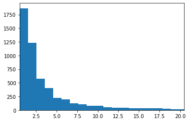

```python
plt.hist([n for t, n in token_counter(text_df[doc]).items()], bins=np.linspace(0.5,50.5))
plt.xlim(0.5,20.5)
```

```python
print("Average Number of Counts per Token:",
      np.array([n for t, n in token_counter(text_df[doc]).items()]).mean())
print("Average Number of Tokens per Document:",
      np.array([len(txt.split()) for txt in text_df[doc]]).mean())
print("Total Number of Unique Tokens:", len(list(token_counter(text_df[doc]))))
```

```
Average Number of Counts per Token: 10.825383008356546
Average Number of Tokens per Document: 59.22
Total Number of Unique Tokens: 5744
```

#### SpaCy

```python
doc = 'document_spacy'
```

```
(0.5, 20.5)
```

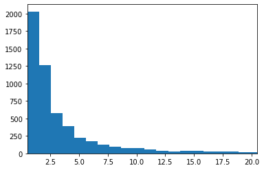

```python
plt.hist([n for t, n in token_counter(text_df[doc]).items()], bins=np.linspace(0.5,50.5))
plt.xlim(0.5,20.5)
```

```python
print("Average Number of Counts per Token:",
      np.array([n for t, n in token_counter(text_df[doc]).items()]).mean())
print("Average Number of Tokens per Document:",
      np.array([len(txt.split()) for txt in text_df[doc]]).mean())
print("Total Number of Unique Tokens:", len(list(token_counter(text_df[doc]))))
```

```
Average Number of Counts per Token: 9.98492117888965
Average Number of Tokens per Document: 55.497142857142855
Total Number of Unique Tokens: 5836
```

### 3.3.2 Chi2 et le pValues des Tokens

#### NLTK et Wordnet

```python
doc = 'document_nltk'
cat = 'category_level1'
```

```python
counter_df = create_observation_matrix(text_df, doc, cat)
indep_df = create_expected_observation_matrix(counter_df)
create_chisquared_measure_matrix(counter_df, indep_df)
```

| category_level1 | specifications | sathiyas | cotton | bath | towel | 3 | red | yellow | blue | features | ... | 241 | firstrace | cb | 108 | 619 | timex | ti000i70600 | 3125 | hands | TOTAL |
| --- | --- | --- | --- | --- | --- | --- | --- | --- | --- | --- | --- | --- | --- | --- | --- | --- | --- | --- | --- | --- | --- |
| Baby Care | 52.493197 | 14.038091 | 460.069563 | 7.822757 | 19.632086 | 0.007807 | 0.482057 | 20.423551 | 61.443152 | 19.046651 | ... | 0.153230 | 0.306460 | 0.306460 | 0.459690 | 0.153230 | 0.306460 | 0.459690 | 0.153230 | 0.306460 | 22859.207596 |
| Beauty and Personal Care | 0.299812 | 0.342838 | 34.169505 | 0.351854 | 10.170856 | 0.143090 | 0.124894 | 6.056802 | 6.880246 | 3.441225 | ... | 0.114279 | 0.228559 | 0.228559 | 0.342838 | 0.114279 | 0.228559 | 0.342838 | 0.114279 | 0.228559 | 21834.854662 |
| Computers | 1.740260 | 0.511796 | 51.009022 | 9.724128 | 15.183287 | 21.825650 | 0.315780 | 0.000193 | 18.520696 | 0.212074 | ... | 0.170599 | 0.341197 | 0.341197 | 0.511796 | 0.170599 | 0.341197 | 0.511796 | 0.170599 | 0.341197 | 25816.887059 |
| Home Decor & Festive Needs | 4.921395 | 0.496985 | 40.037515 | 4.395824 | 14.743877 | 7.620782 | 0.581290 | 2.028218 | 0.757047 | 0.180232 | ... | 0.165662 | 0.331323 | 0.331323 | 0.496985 | 0.165662 | 0.331323 | 0.496985 | 0.165662 | 0.331323 | 19914.818404 |
| Home Furnishing | 2.248322 | 0.353114 | 130.639510 | 95.336062 | 224.767790 | 6.639963 | 0.186416 | 2.268226 | 4.391097 | 3.834849 | ... | 0.117705 | 0.235410 | 0.235410 | 0.353114 | 0.117705 | 0.235410 | 0.353114 | 0.117705 | 0.235410 | 18884.865695 |
| Kitchen & Dining | 4.342312 | 0.540647 | 53.884531 | 10.272302 | 16.039208 | 10.810096 | 0.450865 | 9.551439 | 4.284581 | 2.266603 | ... | 0.180216 | 0.360432 | 0.360432 | 0.540647 | 0.180216 | 0.360432 | 0.540647 | 0.180216 | 0.360432 | 25320.077887 |
| Watches | 14.726262 | 0.294929 | 29.394622 | 5.603657 | 8.749570 | 20.251967 | 0.652059 | 5.210418 | 0.122639 | 12.231450 | ... | 8.270238 | 16.540477 | 16.540477 | 24.810715 | 8.270238 | 16.540477 | 24.810715 | 8.270238 | 16.540477 | 28968.540060 |
| TOTAL | 80.771560 | 16.578401 | 799.204268 | 133.506584 | 309.286674 | 67.299354 | 2.793362 | 45.538846 | 96.399458 | 41.213084 | ... | 9.171929 | 18.343857 | 18.343857 | 27.515786 | 9.171929 | 18.343857 | 27.515786 | 9.171929 | 18.343857 | 163599.251364 |

8 rows × 5745 columns

```python
chi2_values = chisquare(counter_df.iloc[:-1,:-1])
chistats_df = pd.DataFrame(np.array([chi2_values.statistic, chi2_values.pvalue]).T,
                           columns=['Chi2', 'pValue'], index=counter_df.columns[:-1]).join(counter_df.iloc[-1,:].T)
chistats_df.sort_values(by='pValue').iloc[:20,:]
```

|  | Chi2 | pValue | TOTAL |
| --- | --- | --- | --- |
| baby | 1870.479751 | 0.000000e+00 | 321.0 |
| analog | 1489.923664 | 0.000000e+00 | 262.0 |
| mug | 2380.551724 | 0.000000e+00 | 406.0 |
| watch | 1933.166667 | 0.000000e+00 | 336.0 |
| laptop | 1344.000000 | 3.229306e-287 | 224.0 |
| showpiece | 1200.608696 | 3.534225e-256 | 207.0 |
| ceramic | 1140.757991 | 3.164970e-243 | 219.0 |
| usb | 1044.000000 | 2.718037e-222 | 174.0 |
| girl | 972.579882 | 7.612176e-207 | 169.0 |
| coffee | 942.597561 | 2.317106e-200 | 164.0 |
| cm | 934.246914 | 1.480993e-198 | 567.0 |
| details | 923.703704 | 2.819326e-196 | 189.0 |
| men | 820.598870 | 5.451402e-174 | 177.0 |
| cotton | 804.026756 | 2.076921e-170 | 299.0 |
| discounts | 804.000000 | 2.104753e-170 | 134.0 |
| adapter | 786.000000 | 1.630174e-166 | 131.0 |
| fabric | 725.772512 | 1.664969e-153 | 211.0 |
| dress | 630.000000 | 7.862972e-133 | 105.0 |
| perfect | 606.756757 | 8.132922e-128 | 185.0 |
| battery | 546.000000 | 1.028214e-114 | 119.0 |

```python
chistats_df.sort_values(by='pValue', ascending = False).iloc[:20,:]
```

|  | Chi2 | pValue | TOTAL |
| --- | --- | --- | --- |
| touch | 2.352941 | 0.884549 | 17.0 |
| 649 | 2.666667 | 0.849369 | 9.0 |
| 700 | 3.333333 | 0.765996 | 6.0 |
| months | 4.000000 | 0.676676 | 3.0 |
| 1350 | 4.000000 | 0.676676 | 3.0 |
| 138 | 4.000000 | 0.676676 | 3.0 |
| 270 | 4.000000 | 0.676676 | 3.0 |
| least | 4.000000 | 0.676676 | 3.0 |
| monitor | 4.000000 | 0.676676 | 7.0 |
| foldable | 4.000000 | 0.676676 | 3.0 |
| match | 4.000000 | 0.676676 | 3.0 |
| 489 | 4.000000 | 0.676676 | 3.0 |
| functional | 4.000000 | 0.676676 | 3.0 |
| dining | 4.000000 | 0.676676 | 3.0 |
| entire | 4.000000 | 0.676676 | 3.0 |
| field | 4.000000 | 0.676676 | 3.0 |
| gives | 4.000000 | 0.676676 | 3.0 |
| 745 | 4.000000 | 0.676676 | 3.0 |
| 269 | 4.000000 | 0.676676 | 3.0 |
| see | 4.222222 | 0.646632 | 9.0 |

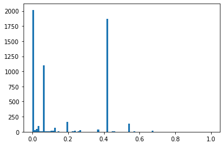

```python
plt.hist(chistats_df['pValue'], bins=np.linspace(0,1, 100))
#plt.xlim(0,0.4)
plt.show()
```

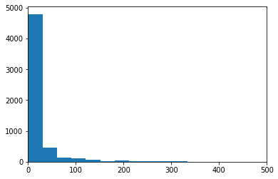

```python
plt.hist(chistats_df['Chi2'], bins=np.linspace(0,3000, 100))
plt.xlim(0,500)
plt.show()
```

```python
nltk_vocab = chistats_df.index.values
```

#### SpaCy

```python
doc = 'document_spacy'
cat = 'category_level1'
```

```python
counter_df = create_observation_matrix(text_df, doc, cat)
indep_df = create_expected_observation_matrix(counter_df)
create_chisquared_measure_matrix(counter_df, indep_df)
```

| category_level1 | specification | sathiyas | cotton | bath | towel | 3 | red | yellow | blue | feature | ... | rs.241 | firstrace | cb | 108 | rs.619 | timex | ti000i70600 | rs.3125 | hands | TOTAL |
| --- | --- | --- | --- | --- | --- | --- | --- | --- | --- | --- | --- | --- | --- | --- | --- | --- | --- | --- | --- | --- | --- |
| Baby Care | 13.909223 | 13.709988 | 443.469008 | 7.832061 | 17.623564 | 14.004903 | 0.398919 | 19.633122 | 54.288720 | 0.119457 | ... | 0.155907 | 0.311814 | 0.311814 | 0.467720 | 0.155907 | 0.311814 | 0.467720 | 0.155907 | 0.311814 | 22012.947658 |
| Beauty and Personal Care | 0.114573 | 0.341742 | 33.946389 | 0.887344 | 10.366179 | 10.512241 | 0.118968 | 6.037445 | 6.632170 | 10.024437 | ... | 0.113914 | 0.227828 | 0.227828 | 0.341742 | 0.113914 | 0.227828 | 0.341742 | 0.113914 | 0.227828 | 21147.021790 |
| Computers | 0.694393 | 0.506641 | 50.326366 | 9.457304 | 15.368118 | 0.657935 | 0.280700 | 0.000272 | 17.978071 | 0.001291 | ... | 0.168880 | 0.337761 | 0.337761 | 0.506641 | 0.168880 | 0.337761 | 0.506641 | 0.168880 | 0.337761 | 25348.611719 |
| Home Decor & Festive Needs | 11.839509 | 0.496654 | 39.841007 | 4.241651 | 15.065160 | 0.920286 | 0.578222 | 2.035198 | 0.639698 | 5.039590 | ... | 0.165551 | 0.331102 | 0.331102 | 0.496654 | 0.165551 | 0.331102 | 0.496654 | 0.165551 | 0.331102 | 19642.395333 |
| Home Furnishing | 7.978387 | 0.360379 | 126.157968 | 94.947808 | 229.324134 | 0.000306 | 0.236041 | 2.073433 | 4.319756 | 2.936050 | ... | 0.120126 | 0.240253 | 0.240253 | 0.360379 | 0.120126 | 0.240253 | 0.360379 | 0.120126 | 0.240253 | 18554.122357 |
| Kitchen & Dining | 22.228717 | 0.532022 | 52.847543 | 9.931082 | 16.138008 | 5.432615 | 0.538766 | 9.399060 | 3.807531 | 55.363890 | ... | 0.177341 | 0.354681 | 0.354681 | 0.532022 | 0.177341 | 0.354681 | 0.532022 | 0.177341 | 0.354681 | 24712.344658 |
| Watches | 3.941175 | 0.294841 | 29.287582 | 5.503707 | 8.943523 | 7.751396 | 0.653517 | 5.208865 | 0.169710 | 5.111180 | ... | 8.273241 | 16.546482 | 16.546482 | 24.819724 | 8.273241 | 16.546482 | 24.819724 | 8.273241 | 16.546482 | 28397.543952 |
| TOTAL | 60.705978 | 16.242267 | 775.875864 | 132.800956 | 312.828687 | 39.279681 | 2.805132 | 44.387395 | 87.835656 | 78.595895 | ... | 9.174961 | 18.349921 | 18.349921 | 27.524882 | 9.174961 | 18.349921 | 27.524882 | 9.174961 | 18.349921 | 159814.987467 |

8 rows × 5837 columns

```python
chi2_values = chisquare(counter_df.iloc[:-1,:-1])
chistats_df = pd.DataFrame(np.array([chi2_values.statistic, chi2_values.pvalue]).T,
                           columns=['Chi2', 'pValue'], index=counter_df.columns[:-1]).join(counter_df.iloc[-1,:].T)
chistats_df.sort_values(by='pValue').iloc[:20,:]
```

|  | Chi2 | pValue | TOTAL |
| --- | --- | --- | --- |
| mug | 2512.523364 | 0.000000e+00 | 428.0 |
| analog | 1489.923664 | 0.000000e+00 | 262.0 |
| baby | 1870.479751 | 0.000000e+00 | 321.0 |
| watch | 1999.129683 | 0.000000e+00 | 347.0 |
| laptop | 1350.000000 | 1.622143e-288 | 225.0 |
| showpiece | 1200.608696 | 3.534225e-256 | 207.0 |
| ceramic | 1140.757991 | 3.164970e-243 | 219.0 |
| usb | 1044.000000 | 2.718037e-222 | 174.0 |
| coffee | 942.597561 | 2.317106e-200 | 164.0 |
| cm | 938.935780 | 1.434557e-199 | 545.0 |
| details | 937.080214 | 3.613552e-199 | 187.0 |
| girl | 913.259259 | 5.108247e-194 | 189.0 |
| cotton | 799.778523 | 1.719182e-169 | 298.0 |
| men | 796.295858 | 9.722813e-169 | 169.0 |
| adapter | 786.000000 | 1.630174e-166 | 131.0 |
| fabric | 725.772512 | 1.664969e-153 | 211.0 |
| dress | 630.000000 | 7.862972e-133 | 105.0 |
| perfect | 606.756757 | 8.132922e-128 | 185.0 |
| discounts | 576.000000 | 3.499130e-121 | 96.0 |
| battery | 557.768595 | 2.985528e-117 | 121.0 |

```python
chistats_df.sort_values(by='pValue', ascending = False).iloc[:20,:]
```

|  | Chi2 | pValue | TOTAL |
| --- | --- | --- | --- |
| touch | 2.352941 | 0.884549 | 17.0 |
| 700 | 3.000000 | 0.808847 | 4.0 |
| 200 | 3.333333 | 0.765996 | 6.0 |
| 270 | 4.000000 | 0.676676 | 3.0 |
| functional | 4.000000 | 0.676676 | 3.0 |
| 275 | 4.000000 | 0.676676 | 3.0 |
| lot | 4.000000 | 0.676676 | 3.0 |
| match | 4.000000 | 0.676676 | 3.0 |
| entire | 4.000000 | 0.676676 | 3.0 |
| 269 | 4.000000 | 0.676676 | 3.0 |
| field | 4.000000 | 0.676676 | 3.0 |
| foldable | 4.000000 | 0.676676 | 3.0 |
| monitor | 4.000000 | 0.676676 | 7.0 |
| content | 4.000000 | 0.676676 | 7.0 |
| cleanse | 4.000000 | 0.676676 | 3.0 |
| rs.450 | 4.000000 | 0.676676 | 3.0 |
| months | 4.000000 | 0.676676 | 3.0 |
| hold | 4.250000 | 0.642885 | 8.0 |
| rich | 4.333333 | 0.631665 | 12.0 |
| convenience | 4.800000 | 0.569709 | 5.0 |

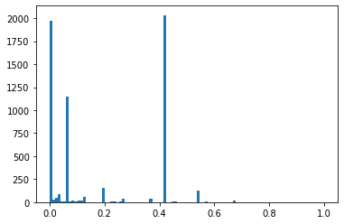

```python
plt.hist(chistats_df['pValue'], bins=np.linspace(0,1, 100))
#plt.xlim(0,0.4)
plt.show()
```

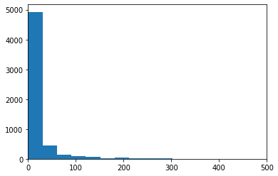

```python
plt.hist(chistats_df['Chi2'], bins=np.linspace(0,3000, 100))
plt.xlim(0,500)
plt.show()
```

```python
spacy_vocab = chistats_df.index.values
```

### 3.3.3 Correlation des Tokens

#### NLTK et Wordnet

```python
doc = 'document_nltk'
cat = 'category_level1'
```

```python
corr_df = drop_unfrequent_tokens(text_df[doc], 10)['document_reduced'].apply(
              lambda x : pd.Series(Counter(x.split()))).fillna(0).corr()
corr_df
```

|  | key | features | elegance | polyester | multicolor | abstract | eyelet | door | curtain | floral | ... | sparklings | smoothing | oudh | shapes | glue | removal | trimning | gum | residue | suitable_for |
| --- | --- | --- | --- | --- | --- | --- | --- | --- | --- | --- | --- | --- | --- | --- | --- | --- | --- | --- | --- | --- | --- |
| key | 1.000000 | 0.621881 | 0.053220 | 0.146257 | 0.267405 | -0.026620 | 0.110624 | 0.103928 | 0.089501 | 0.124357 | ... | 0.065968 | 0.051494 | 0.046625 | 0.145366 | 0.148076 | 0.148076 | 0.148076 | 0.148076 | 0.148076 | 0.137444 |
| features | 0.621881 | 1.000000 | 0.039148 | 0.158341 | 0.223884 | -0.039296 | 0.097547 | 0.121392 | 0.102707 | 0.169734 | ... | 0.107943 | 0.034076 | 0.030854 | 0.095407 | 0.097989 | 0.097989 | 0.097989 | 0.097989 | 0.097989 | 0.089056 |
| elegance | 0.053220 | 0.039148 | 1.000000 | 0.340930 | 0.148596 | 0.350251 | 0.391950 | 0.354582 | 0.518599 | 0.054990 | ... | -0.002860 | -0.002233 | -0.002021 | -0.006626 | -0.006420 | -0.006420 | -0.006420 | -0.006420 | -0.006420 | -0.006736 |
| polyester | 0.146257 | 0.158341 | 0.340930 | 1.000000 | 0.054492 | 0.210628 | 0.809731 | 0.724784 | 0.689887 | 0.160357 | ... | -0.006505 | -0.005078 | -0.004598 | -0.015071 | -0.014603 | -0.014603 | -0.014603 | -0.014603 | -0.014603 | -0.015323 |
| multicolor | 0.267405 | 0.223884 | 0.148596 | 0.054492 | 1.000000 | 0.153035 | 0.084964 | 0.070958 | 0.128068 | 0.093675 | ... | 0.216826 | -0.009057 | -0.008200 | 0.495538 | 0.486700 | 0.486700 | 0.486700 | 0.486700 | 0.486700 | 0.494397 |
| ... | ... | ... | ... | ... | ... | ... | ... | ... | ... | ... | ... | ... | ... | ... | ... | ... | ... | ... | ... | ... | ... |
| removal | 0.148076 | 0.097989 | -0.006420 | -0.014603 | 0.486700 | -0.018123 | -0.011496 | -0.011075 | -0.009472 | -0.016275 | ... | -0.004284 | -0.003344 | -0.003028 | 0.992021 | 1.000000 | 1.000000 | 1.000000 | 1.000000 | 1.000000 | 0.953004 |
| trimning | 0.148076 | 0.097989 | -0.006420 | -0.014603 | 0.486700 | -0.018123 | -0.011496 | -0.011075 | -0.009472 | -0.016275 | ... | -0.004284 | -0.003344 | -0.003028 | 0.992021 | 1.000000 | 1.000000 | 1.000000 | 1.000000 | 1.000000 | 0.953004 |
| gum | 0.148076 | 0.097989 | -0.006420 | -0.014603 | 0.486700 | -0.018123 | -0.011496 | -0.011075 | -0.009472 | -0.016275 | ... | -0.004284 | -0.003344 | -0.003028 | 0.992021 | 1.000000 | 1.000000 | 1.000000 | 1.000000 | 1.000000 | 0.953004 |
| residue | 0.148076 | 0.097989 | -0.006420 | -0.014603 | 0.486700 | -0.018123 | -0.011496 | -0.011075 | -0.009472 | -0.016275 | ... | -0.004284 | -0.003344 | -0.003028 | 0.992021 | 1.000000 | 1.000000 | 1.000000 | 1.000000 | 1.000000 | 0.953004 |
| suitable_for | 0.137444 | 0.089056 | -0.006736 | -0.015323 | 0.494397 | -0.019016 | -0.012063 | -0.011622 | -0.009939 | -0.017078 | ... | -0.004495 | -0.003509 | -0.003177 | 0.983595 | 0.953004 | 0.953004 | 0.953004 | 0.953004 | 0.953004 | 1.000000 |

939 rows × 939 columns

```python
tokens = corr_df.columns.values
corr_tuples_list = []
for i, col in enumerate(tokens) :
    for ind in tokens[:i] :
        corr = corr_df.loc[ind, col]
        if  abs(corr) >= 0.5 :
            corr_tuples_list.append((ind, col, corr))
#print(corr_tuples_list)
```

```python
[x for x in corr_tuples_list if x[2]>0.99]
```

```
[('genuine', 'cash', 1.0),
 ('genuine', 'delivery', 0.9904776794442944),
 ('cash', 'delivery', 0.9904776794442944),
 ('fs', 'klub', 1.0),
 ('selection', 'quote', 1.0),
 ('talk', 'smile', 1.0),
 ('selection', 'forget', 1.0),
 ('quote', 'forget', 1.0),
 ('selection', 'ink', 1.0),
 ('quote', 'ink', 1.0),
 ('forget', 'ink', 1.0),
 ('selection', 'enjoyment', 1.0),
 ('quote', 'enjoyment', 1.0),
 ('forget', 'enjoyment', 1.0),
 ('ink', 'enjoyment', 1.0),
 ('selection', 'freedom', 1.0),
 ('quote', 'freedom', 1.0),
 ('forget', 'freedom', 1.0),
 ('ink', 'freedom', 1.0),
 ('enjoyment', 'freedom', 1.0),
 ('selection', 'broadcast', 1.0),
 ('quote', 'broadcast', 1.0),
 ('forget', 'broadcast', 1.0),
 ('ink', 'broadcast', 1.0),
 ('enjoyment', 'broadcast', 1.0),
 ('freedom', 'broadcast', 1.0),
 ('talk', 'cupcake', 1.0),
 ('smile', 'cupcake', 1.0),
 ('talk', 'laugh', 1.0),
 ('smile', 'laugh', 1.0),
 ('cupcake', 'laugh', 1.0),
 ('selection', 'sipping', 1.0),
 ('quote', 'sipping', 1.0),
 ('forget', 'sipping', 1.0),
 ('ink', 'sipping', 1.0),
 ('enjoyment', 'sipping', 1.0),
 ('freedom', 'sipping', 1.0),
 ('broadcast', 'sipping', 1.0),
 ('thrilling', 'porcelain', 1.0),
 ('thrilling', 'permanent', 1.0),
```

[output cut: 26 more lines]

```
 ('shapes', 'glue', 0.992021151727624),
 ('shapes', 'removal', 0.992021151727624),
 ('glue', 'removal', 1.0),
 ('shapes', 'trimning', 0.992021151727624),
 ('glue', 'trimning', 1.0),
 ('removal', 'trimning', 1.0),
 ('shapes', 'gum', 0.992021151727624),
 ('glue', 'gum', 1.0),
 ('removal', 'gum', 1.0),
 ('trimning', 'gum', 1.0),
 ('shapes', 'residue', 0.992021151727624),
 ('glue', 'residue', 1.0),
 ('removal', 'residue', 1.0),
 ('trimning', 'residue', 1.0),
 ('gum', 'residue', 1.0)]
```

#### SpaCy

```python
doc = 'document_spacy'
cat = 'category_level1'
```

```python
corr_df = drop_unfrequent_tokens(text_df[doc], 10)['document_reduced'].apply(
              lambda x : pd.Series(Counter(x.split()))).fillna(0).corr()
corr_df
```

|  | key | features | elegance | polyester | multicolor | abstract | eyelet | door | curtain | floral | ... | shapes | glue | removal | 15.6 | 329 | 14.1 | trimning | gum | residue | suitable_for |
| --- | --- | --- | --- | --- | --- | --- | --- | --- | --- | --- | --- | --- | --- | --- | --- | --- | --- | --- | --- | --- | --- |
| key | 1.000000 | 0.646382 | 0.052863 | 0.145332 | 0.265726 | -0.029425 | 0.109916 | 0.095343 | 0.091530 | 0.123499 | ... | 0.144532 | 0.147235 | 0.147235 | 0.147235 | 0.147235 | 0.147235 | 0.147235 | 0.147235 | 0.147235 | 0.136642 |
| features | 0.646382 | 1.000000 | 0.043003 | 0.144174 | 0.214803 | -0.039802 | 0.089428 | 0.098613 | 0.092154 | 0.167097 | ... | 0.103332 | 0.105981 | 0.105981 | 0.105981 | 0.105981 | 0.105981 | 0.105981 | 0.105981 | 0.105981 | 0.096666 |
| elegance | 0.052863 | 0.043003 | 1.000000 | 0.340930 | 0.148596 | 0.345511 | 0.391950 | 0.357897 | 0.498179 | 0.054990 | ... | -0.006626 | -0.006420 | -0.006420 | -0.006420 | -0.006420 | -0.006420 | -0.006420 | -0.006420 | -0.006420 | -0.006736 |
| polyester | 0.145332 | 0.144174 | 0.340930 | 1.000000 | 0.054492 | 0.206993 | 0.809731 | 0.731648 | 0.699062 | 0.160357 | ... | -0.015071 | -0.014603 | -0.014603 | -0.014603 | -0.014603 | -0.014603 | -0.014603 | -0.014603 | -0.014603 | -0.015323 |
| multicolor | 0.265726 | 0.214803 | 0.148596 | 0.054492 | 1.000000 | 0.149267 | 0.084964 | 0.073096 | 0.122018 | 0.093675 | ... | 0.495538 | 0.486700 | 0.486700 | 0.486700 | 0.486700 | 0.486700 | 0.486700 | 0.486700 | 0.486700 | 0.494397 |
| ... | ... | ... | ... | ... | ... | ... | ... | ... | ... | ... | ... | ... | ... | ... | ... | ... | ... | ... | ... | ... | ... |
| 14.1 | 0.147235 | 0.105981 | -0.006420 | -0.014603 | 0.486700 | -0.018604 | -0.011496 | -0.010594 | -0.009500 | -0.016275 | ... | 0.992021 | 1.000000 | 1.000000 | 1.000000 | 1.000000 | 1.000000 | 1.000000 | 1.000000 | 1.000000 | 0.953004 |
| trimning | 0.147235 | 0.105981 | -0.006420 | -0.014603 | 0.486700 | -0.018604 | -0.011496 | -0.010594 | -0.009500 | -0.016275 | ... | 0.992021 | 1.000000 | 1.000000 | 1.000000 | 1.000000 | 1.000000 | 1.000000 | 1.000000 | 1.000000 | 0.953004 |
| gum | 0.147235 | 0.105981 | -0.006420 | -0.014603 | 0.486700 | -0.018604 | -0.011496 | -0.010594 | -0.009500 | -0.016275 | ... | 0.992021 | 1.000000 | 1.000000 | 1.000000 | 1.000000 | 1.000000 | 1.000000 | 1.000000 | 1.000000 | 0.953004 |
| residue | 0.147235 | 0.105981 | -0.006420 | -0.014603 | 0.486700 | -0.018604 | -0.011496 | -0.010594 | -0.009500 | -0.016275 | ... | 0.992021 | 1.000000 | 1.000000 | 1.000000 | 1.000000 | 1.000000 | 1.000000 | 1.000000 | 1.000000 | 0.953004 |
| suitable_for | 0.136642 | 0.096666 | -0.006736 | -0.015323 | 0.494397 | -0.019521 | -0.012063 | -0.011117 | -0.009968 | -0.017078 | ... | 0.983595 | 0.953004 | 0.953004 | 0.953004 | 0.953004 | 0.953004 | 0.953004 | 0.953004 | 0.953004 | 1.000000 |

889 rows × 889 columns

```python
tokens = corr_df.columns.values
corr_tuples_list = []
for i, col in enumerate(tokens) :
    for ind in tokens[:i] :
        corr = corr_df.loc[ind, col]
        if  abs(corr) >= 0.5 :
            corr_tuples_list.append((ind, col, corr))
#print(corr_tuples_list)
```

```python
[x for x in corr_tuples_list if x[2]>0.99]
```

```
[('genuine', 'shipping', 1.0),
 ('genuine', 'cash', 1.0),
 ('shipping', 'cash', 1.0),
 ('genuine', 'delivery', 0.9904776794442944),
 ('shipping', 'delivery', 0.9904776794442944),
 ('cash', 'delivery', 0.9904776794442944),
 ('fs', 'klub', 1.0),
 ('talk', 'selection', 1.0),
 ('talk', 'quote', 1.0),
 ('selection', 'quote', 1.0),
 ('talk', 'say', 1.0),
 ('selection', 'say', 1.0),
 ('quote', 'say', 1.0),
 ('talk', 'forget', 1.0),
 ('selection', 'forget', 1.0),
 ('quote', 'forget', 1.0),
 ('say', 'forget', 1.0),
 ('talk', 'ink', 1.0),
 ('selection', 'ink', 1.0),
 ('quote', 'ink', 1.0),
 ('say', 'ink', 1.0),
 ('forget', 'ink', 1.0),
 ('talk', 'enjoyment', 1.0),
 ('selection', 'enjoyment', 1.0),
 ('quote', 'enjoyment', 1.0),
 ('say', 'enjoyment', 1.0),
 ('forget', 'enjoyment', 1.0),
 ('ink', 'enjoyment', 1.0),
 ('talk', 'freedom', 1.0),
 ('selection', 'freedom', 1.0),
 ('quote', 'freedom', 1.0),
 ('say', 'freedom', 1.0),
 ('forget', 'freedom', 1.0),
 ('ink', 'freedom', 1.0),
 ('enjoyment', 'freedom', 1.0),
 ('talk', 'broadcast', 1.0),
 ('selection', 'broadcast', 1.0),
 ('quote', 'broadcast', 1.0),
 ('say', 'broadcast', 1.0),
 ('forget', 'broadcast', 1.0),
```

[output cut: 67 more lines]

```
 ('shapes', 'gum', 0.992021151727624),
 ('glue', 'gum', 1.0),
 ('removal', 'gum', 1.0),
 ('15.6', 'gum', 1.0),
 ('329', 'gum', 1.0),
 ('14.1', 'gum', 1.0),
 ('trimning', 'gum', 1.0),
 ('shapes', 'residue', 0.992021151727624),
 ('glue', 'residue', 1.0),
 ('removal', 'residue', 1.0),
 ('15.6', 'residue', 1.0),
 ('329', 'residue', 1.0),
 ('14.1', 'residue', 1.0),
 ('trimning', 'residue', 1.0),
 ('gum', 'residue', 1.0)]
```

### 3.3.4 Comparison du Vocabulaire NLTK et SpaCy

```python
set(nltk_vocab)-set(spacy_vocab)
```

```
{'!!',
 '!!!',
 '!,',
 '",',
 '"-',
 '".',
 '".,',
 '";',
 '##',
 '%!',
 "''",
 '(-',
 ')"',
 '),',
 ')-',
 ').',
 ')/',
 ')//',
 ');',
 ');,',
 '**',
 '++',
 '+++',
 ',)',
 ',,',
 ',.',
 ',@',
 '."',
 '.",',
 '.)',
 '.),',
 '.).',
 '.**',
 '.,',
 '..',
 '...',
 '.....,',
 '...................',
 '......................',
 './',
```

[output cut: 626 more lines]

```
 'withstands',
 'works',
 'would',
 'wrapped',
 'x6',
 'y430g',
 'yet',
 'yr',
 '±',
 '“',
 '”',
 '•',
 '…,',
 '….,',
 '��'}
```

```python
set(spacy_vocab)-set(nltk_vocab)
```

```
{'",specification',
 '+60c',
 '+70c',
 ',am',
 ',loreal',
 ',prisha',
 ',royle',
 ',services',
 ',smart',
 ',specification',
 ',specifications',
 ',vareesha',
 ',wall',
 ',ygs',
 '-1001',
 '-15',
 '-20',
 '-200',
 '-20c-',
 '-23',
 '-300',
 '-30c',
 '-4',
 '-a',
 '-age',
 '-available',
 '-avoid',
 '-blue',
 '-includes',
 '-keeps',
 '-material',
 '-one',
 '-reusable',
 '-size',
 '-snap',
 '-trim',
 '-tumble',
 '-wash',
 '.,specification',
 '.,specifications',
```

[output cut: 718 more lines]

```
 'v1.1',
 'vj-552',
 'vj-556',
 'vj-580',
 'walk',
 'wall,300',
 'wash.',
 'wf-2301',
 'width:20mm',
 'width:30',
 'win10/',
 'y430',
 'you`d',
 'yrs',
 '±3'}
```

## 3.4 La Tokenisation de la Description - 2

```python
punctuation_signs = [s for s in string.punctuation] + ['–','?','.','’', '°', '±', '“', '”', '•', '…', '�', '��']
digits = [i for i in string.digits]
char_list = digits + punctuation_signs

single_letters = [l for l in string.ascii_letters]
all_my_stopwords += single_letters
```

### 3.4.1 Tokenisation et Lemmatisation avec NLTK and Wordnet

```python
text_df = text_df.merge(tokenize_and_lemmatize_with_nltk(text_df['description'].apply(
                        lambda x : replace_chars_with_space(x, char_list)),
                        stopwords = all_my_stopwords), left_index=True, right_index=True)
```

```python
text_df
```

|  | image_id | product_name | product_category_tree | image_file | description | brand | product_specifications | category_list | category_tree_depth | category_level1 | ... | category_level5 | tokens_with_pos_nltk | lemmas_nltk | document_nltk | tokens_spacy | lemmas_spacy | document_spacy | tokens_with_pos | lemmas | document |
| --- | --- | --- | --- | --- | --- | --- | --- | --- | --- | --- | --- | --- | --- | --- | --- | --- | --- | --- | --- | --- | --- |
| 0 | 55b85ea15a1536d46b7190ad6fff8ce7 | Elegance Polyester Multicolor Abstract Eyelet ... | ["Home Furnishing >> Curtains & Accessories >>... | 55b85ea15a1536d46b7190ad6fff8ce7.jpg | Key Features of Elegance Polyester Multicolor ... | Elegance | {"product_specification"=>[{"key"=>"Brand", "v... | [Home Furnishing, Curtains & Accessories, Curt... | 4 | Home Furnishing | ... | NaN | [(Key, NNP), (Features, NNP), (of, IN), (Elega... | [key, features, elegance, polyester, multicolo... | key features elegance polyester multicolor abs... | [Key, Features, of, Elegance, Polyester, Multi... | [key, features, elegance, polyester, multicolo... | key features elegance polyester multicolor abs... | [(Key, NNP), (Features, NNP), (of, IN), (Elega... | [key, features, elegance, polyester, multicolo... | key features elegance polyester multicolor abs... |
| 1 | 7b72c92c2f6c40268628ec5f14c6d590 | Sathiyas Cotton Bath Towel | ["Baby Care >> Baby Bath & Skin >> Baby Bath T... | 7b72c92c2f6c40268628ec5f14c6d590.jpg | Specifications of Sathiyas Cotton Bath Towel (... | Sathiyas | {"product_specification"=>[{"key"=>"Machine Wa... | [Baby Care, Baby Bath & Skin, Baby Bath Towels... | 5 | Baby Care | ... | Sathiyas Cotton Bath Towel (3 Bath Towel, Red,... | [(Specifications, NNS), (of, IN), (Sathiyas, N... | [specifications, sathiyas, cotton, bath, towel... | specifications sathiyas cotton bath towel 3 ba... | [Specifications, of, Sathiyas, Cotton, Bath, T... | [specification, sathiyas, cotton, bath, towel,... | specification sathiyas cotton bath towel 3 bat... | [(Specifications, NNS), (of, IN), (Sathiyas, N... | [specifications, sathiyas, cotton, bath, towel... | specifications sathiyas cotton bath towel bath... |
| 2 | 64d5d4a258243731dc7bbb1eef49ad74 | Eurospa Cotton Terry Face Towel Set | ["Baby Care >> Baby Bath & Skin >> Baby Bath T... | 64d5d4a258243731dc7bbb1eef49ad74.jpg | Key Features of Eurospa Cotton Terry Face Towe... | Eurospa | {"product_specification"=>[{"key"=>"Material",... | [Baby Care, Baby Bath & Skin, Baby Bath Towels... | 5 | Baby Care | ... | Eurospa Cotton Terry Face Towel Set (20 PIECE ... | [(Key, NNP), (Features, NNP), (of, IN), (Euros... | [key, features, eurospa, cotton, terry, face, ... | key features eurospa cotton terry face towel s... | [Key, Features, of, Eurospa, Cotton, Terry, Fa... | [key, features, eurospa, cotton, terry, face, ... | key features eurospa cotton terry face towel s... | [(Key, NNP), (Features, NNP), (of, IN), (Euros... | [key, features, eurospa, cotton, terry, face, ... | key features eurospa cotton terry face towel s... |
| 3 | d4684dcdc759dd9cdf41504698d737d8 | SANTOSH ROYAL FASHION Cotton Printed King size... | ["Home Furnishing >> Bed Linen >> Bedsheets >>... | d4684dcdc759dd9cdf41504698d737d8.jpg | Key Features of SANTOSH ROYAL FASHION Cotton P... | SANTOSH ROYAL FASHION | {"product_specification"=>[{"key"=>"Brand", "v... | [Home Furnishing, Bed Linen, Bedsheets, SANTOS... | 5 | Home Furnishing | ... | SANTOSH ROYAL FASHION Cotton Printed King size... | [(Key, NNP), (Features, NNP), (of, IN), (SANTO... | [key, features, santosh, royal, fashion, cotto... | key features santosh royal fashion cotton prin... | [Key, Features, of, SANTOSH, ROYAL, FASHION, C... | [key, features, santosh, royal, fashion, cotto... | key features santosh royal fashion cotton prin... | [(Key, NNP), (Features, NNP), (of, IN), (SANTO... | [key, features, santosh, royal, fashion, cotto... | key features santosh royal fashion cotton prin... |
| 4 | 6325b6870c54cd47be6ebfbffa620ec7 | Jaipur Print Cotton Floral King sized Double B... | ["Home Furnishing >> Bed Linen >> Bedsheets >>... | 6325b6870c54cd47be6ebfbffa620ec7.jpg | Key Features of Jaipur Print Cotton Floral Kin... | Jaipur Print | {"product_specification"=>[{"key"=>"Machine Wa... | [Home Furnishing, Bed Linen, Bedsheets, Jaipur... | 5 | Home Furnishing | ... | Jaipur Print Cotton Floral King sized Double B... | [(Key, NNP), (Features, NNP), (of, IN), (Jaipu... | [key, features, jaipur, print, cotton, floral,... | key features jaipur print cotton floral king s... | [Key, Features, of, Jaipur, Print, Cotton, Flo... | [key, features, jaipur, print, cotton, floral,... | key features jaipur print cotton floral king s... | [(Key, NNP), (Features, NNP), (of, IN), (Jaipu... | [key, features, jaipur, print, cotton, floral,... | key features jaipur print cotton floral king s... |
| ... | ... | ... | ... | ... | ... | ... | ... | ... | ... | ... | ... | ... | ... | ... | ... | ... | ... | ... | ... | ... | ... |
| 1045 | 958f54f4c46b53c8a0a9b8167d9140bc | Oren Empower Extra Large Self Adhesive Sticker | ["Baby Care >> Baby & Kids Gifts >> Stickers >... | 958f54f4c46b53c8a0a9b8167d9140bc.jpg | Oren Empower Extra Large Self Adhesive Sticker... | Oren Empower | {"product_specification"=>[{"key"=>"Number of ... | [Baby Care, Baby & Kids Gifts, Stickers, Oren ... | 4 | Baby Care | ... | NaN | [(Oren, NNP), (Empower, NNP), (Extra, NNP), (L... | [oren, empower, extra, large, self, adhesive, ... | oren empower extra large self adhesive sticker... | [Oren, Empower, Extra, Large, Self, Adhesive, ... | [oren, empower, extra, large, self, adhesive, ... | oren empower extra large self adhesive sticker... | [(Oren, NNP), (Empower, NNP), (Extra, NNP), (L... | [oren, empower, extra, large, self, adhesive, ... | oren empower extra large self adhesive sticker... |
| 1046 | fd6cbcc22efb6b761bd564c28928483c | Wallmantra Large Vinyl Sticker Sticker | ["Baby Care >> Baby & Kids Gifts >> Stickers >... | fd6cbcc22efb6b761bd564c28928483c.jpg | Wallmantra Large Vinyl Sticker Sticker (Pack o... | Wallmantra | {"product_specification"=>[{"key"=>"Number of ... | [Baby Care, Baby & Kids Gifts, Stickers, Wallm... | 4 | Baby Care | ... | NaN | [(Wallmantra, NNP), (Large, NNP), (Vinyl, NNP)... | [wallmantra, large, vinyl, sticker, sticker, p... | wallmantra large vinyl sticker sticker pack 1 ... | [Wallmantra, Large, Vinyl, Sticker, Sticker, (... | [wallmantra, large, vinyl, sticker, sticker, p... | wallmantra large vinyl sticker sticker pack 1 ... | [(Wallmantra, NNP), (Large, NNP), (Vinyl, NNP)... | [wallmantra, large, vinyl, sticker, sticker, p... | wallmantra large vinyl sticker sticker pack pr... |
| 1047 | 5912e037d12774bb73a2048f35a00009 | Uberlyfe Extra Large Pigmented Polyvinyl Films... | ["Baby Care >> Baby & Kids Gifts >> Stickers >... | 5912e037d12774bb73a2048f35a00009.jpg | Buy Uberlyfe Extra Large Pigmented Polyvinyl F... | Uberlyfe | {"product_specification"=>[{"key"=>"Number of ... | [Baby Care, Baby & Kids Gifts, Stickers, Uberl... | 4 | Baby Care | ... | NaN | [(Buy, NNP), (Uberlyfe, NNP), (Extra, NNP), (L... | [buy, uberlyfe, extra, large, pigmented, polyv... | buy uberlyfe extra large pigmented polyvinyl f... | [Buy, Uberlyfe, Extra, Large, Pigmented, Polyv... | [buy, uberlyfe, extra, large, pigment, polyvin... | buy uberlyfe extra large pigment polyvinyl fil... | [(Buy, NNP), (Uberlyfe, NNP), (Extra, NNP), (L... | [buy, uberlyfe, extra, large, pigmented, polyv... | buy uberlyfe extra large pigmented polyvinyl f... |
| 1048 | c3edc504d1b4f0ba6224fa53a43a7ad6 | Wallmantra Medium Vinyl Sticker Sticker | ["Baby Care >> Baby & Kids Gifts >> Stickers >... | c3edc504d1b4f0ba6224fa53a43a7ad6.jpg | Buy Wallmantra Medium Vinyl Sticker Sticker fo... | Wallmantra | {"product_specification"=>[{"key"=>"Number of ... | [Baby Care, Baby & Kids Gifts, Stickers, Wallm... | 4 | Baby Care | ... | NaN | [(Buy, NNP), (Wallmantra, NNP), (Medium, NNP),... | [buy, wallmantra, medium, vinyl, sticker, stic... | buy wallmantra medium vinyl sticker sticker rs... | [Buy, Wallmantra, Medium, Vinyl, Sticker, Stic... | [buy, wallmantra, medium, vinyl, sticker, stic... | buy wallmantra medium vinyl sticker sticker rs... | [(Buy, NNP), (Wallmantra, NNP), (Medium, NNP),... | [buy, wallmantra, medium, vinyl, sticker, stic... | buy wallmantra medium vinyl sticker sticker rs... |
| 1049 | f2f027ad6a6df617c9f125173da71e44 | Uberlyfe Large Vinyl Sticker | ["Baby Care >> Baby & Kids Gifts >> Stickers >... | f2f027ad6a6df617c9f125173da71e44.jpg | Buy Uberlyfe Large Vinyl Sticker for Rs.595 on... | Uberlyfe | {"product_specification"=>[{"key"=>"Sales Pack... | [Baby Care, Baby & Kids Gifts, Stickers, Uberl... | 4 | Baby Care | ... | NaN | [(Buy, NNP), (Uberlyfe, NNP), (Large, NNP), (V... | [buy, uberlyfe, large, vinyl, sticker, rs, 595... | buy uberlyfe large vinyl sticker rs 595 online... | [Buy, Uberlyfe, Large, Vinyl, Sticker, for, Rs... | [buy, uberlyfe, large, vinyl, sticker, rs.595,... | buy uberlyfe large vinyl sticker rs.595 online... | [(Buy, NNP), (Uberlyfe, NNP), (Large, NNP), (V... | [buy, uberlyfe, large, vinyl, sticker, rs, onl... | buy uberlyfe large vinyl sticker rs online ube... |

1050 rows × 23 columns

```python
text_df = text_df.rename(columns = {'tokens_with_pos' : 'tokens_with_pos_nltk_2',
                                    'lemmas' : 'lemmas_nltk_2',
                                    'document' : 'document_nltk_2'})
```

### 3.2.2 Tokenisation et Lemmatisation avex SpaCy

```python
for s in single_letters:
    nlp.Defaults.stop_words.add(s)
```

```python
text_df = text_df.merge(tokenize_and_lemmatize_with_spacy(text_df['description'].apply(
                        lambda x : replace_chars_with_space(x, char_list)), stopwords = single_letters),
                        left_index=True, right_index=True)
```

```python
text_df
```

|  | image_id | product_name | product_category_tree | image_file | description | brand | product_specifications | category_list | category_tree_depth | category_level1 | ... | document_nltk | tokens_spacy | lemmas_spacy | document_spacy | tokens_with_pos_nltk_2 | lemmas_nltk_2 | document_nltk_2 | tokens | lemmas | document |
| --- | --- | --- | --- | --- | --- | --- | --- | --- | --- | --- | --- | --- | --- | --- | --- | --- | --- | --- | --- | --- | --- |
| 0 | 55b85ea15a1536d46b7190ad6fff8ce7 | Elegance Polyester Multicolor Abstract Eyelet ... | ["Home Furnishing >> Curtains & Accessories >>... | 55b85ea15a1536d46b7190ad6fff8ce7.jpg | Key Features of Elegance Polyester Multicolor ... | Elegance | {"product_specification"=>[{"key"=>"Brand", "v... | [Home Furnishing, Curtains & Accessories, Curt... | 4 | Home Furnishing | ... | key features elegance polyester multicolor abs... | [Key, Features, of, Elegance, Polyester, Multi... | [key, features, elegance, polyester, multicolo... | key features elegance polyester multicolor abs... | [(Key, NNP), (Features, NNP), (of, IN), (Elega... | [key, features, elegance, polyester, multicolo... | key features elegance polyester multicolor abs... | [Key, Features, of, Elegance, Polyester, Multi... | [key, features, elegance, polyester, multicolo... | key features elegance polyester multicolor abs... |
| 1 | 7b72c92c2f6c40268628ec5f14c6d590 | Sathiyas Cotton Bath Towel | ["Baby Care >> Baby Bath & Skin >> Baby Bath T... | 7b72c92c2f6c40268628ec5f14c6d590.jpg | Specifications of Sathiyas Cotton Bath Towel (... | Sathiyas | {"product_specification"=>[{"key"=>"Machine Wa... | [Baby Care, Baby Bath & Skin, Baby Bath Towels... | 5 | Baby Care | ... | specifications sathiyas cotton bath towel 3 ba... | [Specifications, of, Sathiyas, Cotton, Bath, T... | [specification, sathiyas, cotton, bath, towel,... | specification sathiyas cotton bath towel 3 bat... | [(Specifications, NNS), (of, IN), (Sathiyas, N... | [specifications, sathiyas, cotton, bath, towel... | specifications sathiyas cotton bath towel bath... | [Specifications, of, Sathiyas, Cotton, Bath, T... | [specification, sathiyas, cotton, bath, towel,... | specification sathiyas cotton bath towel bath ... |
| 2 | 64d5d4a258243731dc7bbb1eef49ad74 | Eurospa Cotton Terry Face Towel Set | ["Baby Care >> Baby Bath & Skin >> Baby Bath T... | 64d5d4a258243731dc7bbb1eef49ad74.jpg | Key Features of Eurospa Cotton Terry Face Towe... | Eurospa | {"product_specification"=>[{"key"=>"Material",... | [Baby Care, Baby Bath & Skin, Baby Bath Towels... | 5 | Baby Care | ... | key features eurospa cotton terry face towel s... | [Key, Features, of, Eurospa, Cotton, Terry, Fa... | [key, features, eurospa, cotton, terry, face, ... | key features eurospa cotton terry face towel s... | [(Key, NNP), (Features, NNP), (of, IN), (Euros... | [key, features, eurospa, cotton, terry, face, ... | key features eurospa cotton terry face towel s... | [Key, Features, of, Eurospa, Cotton, Terry, Fa... | [key, features, eurospa, cotton, terry, face, ... | key features eurospa cotton terry face towel s... |
| 3 | d4684dcdc759dd9cdf41504698d737d8 | SANTOSH ROYAL FASHION Cotton Printed King size... | ["Home Furnishing >> Bed Linen >> Bedsheets >>... | d4684dcdc759dd9cdf41504698d737d8.jpg | Key Features of SANTOSH ROYAL FASHION Cotton P... | SANTOSH ROYAL FASHION | {"product_specification"=>[{"key"=>"Brand", "v... | [Home Furnishing, Bed Linen, Bedsheets, SANTOS... | 5 | Home Furnishing | ... | key features santosh royal fashion cotton prin... | [Key, Features, of, SANTOSH, ROYAL, FASHION, C... | [key, features, santosh, royal, fashion, cotto... | key features santosh royal fashion cotton prin... | [(Key, NNP), (Features, NNP), (of, IN), (SANTO... | [key, features, santosh, royal, fashion, cotto... | key features santosh royal fashion cotton prin... | [Key, Features, of, SANTOSH, ROYAL, FASHION, C... | [key, features, santosh, royal, fashion, cotto... | key features santosh royal fashion cotton prin... |
| 4 | 6325b6870c54cd47be6ebfbffa620ec7 | Jaipur Print Cotton Floral King sized Double B... | ["Home Furnishing >> Bed Linen >> Bedsheets >>... | 6325b6870c54cd47be6ebfbffa620ec7.jpg | Key Features of Jaipur Print Cotton Floral Kin... | Jaipur Print | {"product_specification"=>[{"key"=>"Machine Wa... | [Home Furnishing, Bed Linen, Bedsheets, Jaipur... | 5 | Home Furnishing | ... | key features jaipur print cotton floral king s... | [Key, Features, of, Jaipur, Print, Cotton, Flo... | [key, features, jaipur, print, cotton, floral,... | key features jaipur print cotton floral king s... | [(Key, NNP), (Features, NNP), (of, IN), (Jaipu... | [key, features, jaipur, print, cotton, floral,... | key features jaipur print cotton floral king s... | [Key, Features, of, Jaipur, Print, Cotton, Flo... | [key, features, jaipur, print, cotton, floral,... | key features jaipur print cotton floral king s... |
| ... | ... | ... | ... | ... | ... | ... | ... | ... | ... | ... | ... | ... | ... | ... | ... | ... | ... | ... | ... | ... | ... |
| 1045 | 958f54f4c46b53c8a0a9b8167d9140bc | Oren Empower Extra Large Self Adhesive Sticker | ["Baby Care >> Baby & Kids Gifts >> Stickers >... | 958f54f4c46b53c8a0a9b8167d9140bc.jpg | Oren Empower Extra Large Self Adhesive Sticker... | Oren Empower | {"product_specification"=>[{"key"=>"Number of ... | [Baby Care, Baby & Kids Gifts, Stickers, Oren ... | 4 | Baby Care | ... | oren empower extra large self adhesive sticker... | [Oren, Empower, Extra, Large, Self, Adhesive, ... | [oren, empower, extra, large, self, adhesive, ... | oren empower extra large self adhesive sticker... | [(Oren, NNP), (Empower, NNP), (Extra, NNP), (L... | [oren, empower, extra, large, self, adhesive, ... | oren empower extra large self adhesive sticker... | [Oren, Empower, Extra, Large, Self, Adhesive, ... | [oren, empower, extra, large, self, adhesive, ... | oren empower extra large self adhesive sticker... |
| 1046 | fd6cbcc22efb6b761bd564c28928483c | Wallmantra Large Vinyl Sticker Sticker | ["Baby Care >> Baby & Kids Gifts >> Stickers >... | fd6cbcc22efb6b761bd564c28928483c.jpg | Wallmantra Large Vinyl Sticker Sticker (Pack o... | Wallmantra | {"product_specification"=>[{"key"=>"Number of ... | [Baby Care, Baby & Kids Gifts, Stickers, Wallm... | 4 | Baby Care | ... | wallmantra large vinyl sticker sticker pack 1 ... | [Wallmantra, Large, Vinyl, Sticker, Sticker, (... | [wallmantra, large, vinyl, sticker, sticker, p... | wallmantra large vinyl sticker sticker pack 1 ... | [(Wallmantra, NNP), (Large, NNP), (Vinyl, NNP)... | [wallmantra, large, vinyl, sticker, sticker, p... | wallmantra large vinyl sticker sticker pack pr... | [Wallmantra, Large, Vinyl, Sticker, Sticker, ... | [wallmantra, large, vinyl, sticker, sticker, p... | wallmantra large vinyl sticker sticker pack pr... |
| 1047 | 5912e037d12774bb73a2048f35a00009 | Uberlyfe Extra Large Pigmented Polyvinyl Films... | ["Baby Care >> Baby & Kids Gifts >> Stickers >... | 5912e037d12774bb73a2048f35a00009.jpg | Buy Uberlyfe Extra Large Pigmented Polyvinyl F... | Uberlyfe | {"product_specification"=>[{"key"=>"Number of ... | [Baby Care, Baby & Kids Gifts, Stickers, Uberl... | 4 | Baby Care | ... | buy uberlyfe extra large pigmented polyvinyl f... | [Buy, Uberlyfe, Extra, Large, Pigmented, Polyv... | [buy, uberlyfe, extra, large, pigment, polyvin... | buy uberlyfe extra large pigment polyvinyl fil... | [(Buy, NNP), (Uberlyfe, NNP), (Extra, NNP), (L... | [buy, uberlyfe, extra, large, pigmented, polyv... | buy uberlyfe extra large pigmented polyvinyl f... | [Buy, Uberlyfe, Extra, Large, Pigmented, Polyv... | [buy, uberlyfe, extra, large, pigment, polyvin... | buy uberlyfe extra large pigment polyvinyl fil... |
| 1048 | c3edc504d1b4f0ba6224fa53a43a7ad6 | Wallmantra Medium Vinyl Sticker Sticker | ["Baby Care >> Baby & Kids Gifts >> Stickers >... | c3edc504d1b4f0ba6224fa53a43a7ad6.jpg | Buy Wallmantra Medium Vinyl Sticker Sticker fo... | Wallmantra | {"product_specification"=>[{"key"=>"Number of ... | [Baby Care, Baby & Kids Gifts, Stickers, Wallm... | 4 | Baby Care | ... | buy wallmantra medium vinyl sticker sticker rs... | [Buy, Wallmantra, Medium, Vinyl, Sticker, Stic... | [buy, wallmantra, medium, vinyl, sticker, stic... | buy wallmantra medium vinyl sticker sticker rs... | [(Buy, NNP), (Wallmantra, NNP), (Medium, NNP),... | [buy, wallmantra, medium, vinyl, sticker, stic... | buy wallmantra medium vinyl sticker sticker rs... | [Buy, Wallmantra, Medium, Vinyl, Sticker, Stic... | [buy, wallmantra, medium, vinyl, sticker, stic... | buy wallmantra medium vinyl sticker sticker rs... |
| 1049 | f2f027ad6a6df617c9f125173da71e44 | Uberlyfe Large Vinyl Sticker | ["Baby Care >> Baby & Kids Gifts >> Stickers >... | f2f027ad6a6df617c9f125173da71e44.jpg | Buy Uberlyfe Large Vinyl Sticker for Rs.595 on... | Uberlyfe | {"product_specification"=>[{"key"=>"Sales Pack... | [Baby Care, Baby & Kids Gifts, Stickers, Uberl... | 4 | Baby Care | ... | buy uberlyfe large vinyl sticker rs 595 online... | [Buy, Uberlyfe, Large, Vinyl, Sticker, for, Rs... | [buy, uberlyfe, large, vinyl, sticker, rs.595,... | buy uberlyfe large vinyl sticker rs.595 online... | [(Buy, NNP), (Uberlyfe, NNP), (Large, NNP), (V... | [buy, uberlyfe, large, vinyl, sticker, rs, onl... | buy uberlyfe large vinyl sticker rs online ube... | [Buy, Uberlyfe, Large, Vinyl, Sticker, for, Rs... | [buy, uberlyfe, large, vinyl, sticker, rs, onl... | buy uberlyfe large vinyl sticker rs online ube... |

1050 rows × 26 columns

```python
text_df = text_df.rename(columns = {'tokens' : 'tokens_spacy_2',
                                    'lemmas' : 'lemmas_spacy_2',
                                    'document' : 'document_spacy_2'})
```

## 3.5 Fréquence, Chi2 et pValue des Tokens - 2

### 3.5.1 Fréquence des Tokens dans le Corpus

#### NLTK et WordNet

```python
doc = 'document_nltk_2'
```

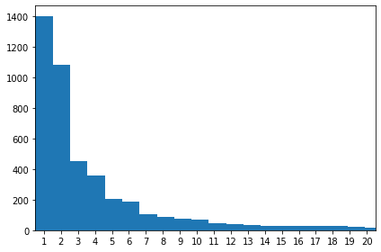

```python
plt.hist([n for t, n in token_counter(text_df[doc]).items()], bins=np.linspace(0.5,50.5))
plt.xlim(0.5,20.5)
plt.xticks(np.linspace(1,20,20))
plt.tight_layout()
```

```
(0.5, 1000.5)
```

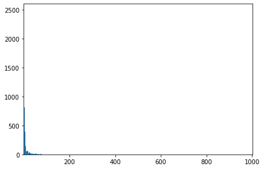

```python
plt.hist([n for t, n in token_counter(text_df[doc]).items()], bins=500)
plt.tight_layout()
plt.xlim(0.5,1000.5)
```

```python
print("Average Number of Counts per Token:",
      np.array([n for t, n in token_counter(text_df[doc]).items()]).mean())
print("Average Number of Tokens per Document:",
      np.array([len(txt.split()) for txt in text_df[doc]]).mean())
print("Total Number of Unique Tokens:", len(list(token_counter(text_df[doc]))))
```

```
Average Number of Counts per Token: 11.6759741612836
Average Number of Tokens per Document: 53.364761904761906
Total Number of Unique Tokens: 4799
```

#### SpaCy

```python
doc = 'document_spacy_2'
```

```
(0.5, 20.5)
```

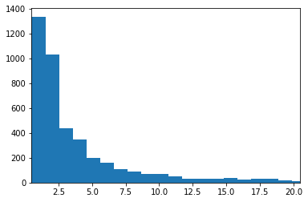

```python
plt.hist([n for t, n in token_counter(text_df[doc]).items()], bins=np.linspace(0.5,50.5))
plt.xlim(0.5,20.5)
```

```python
print("Average Number of Counts per Token:",
      np.array([n for t, n in token_counter(text_df[doc]).items()]).mean())
print("Average Number of Tokens per Document:",
      np.array([len(txt.split()) for txt in text_df[doc]]).mean())
print("Total Number of Unique Tokens:", len(list(token_counter(text_df[doc]))))
```

```
Average Number of Counts per Token: 11.632356134636264
Average Number of Tokens per Document: 51.016190476190474
Total Number of Unique Tokens: 4605
```

### 3.5.2 Chi2 et le pValues des Tokens

#### NLTK et Wordnet

```python
doc = 'document_nltk_2'
cat = 'category_level1'
```

```python
counter_df = create_observation_matrix(text_df, doc, cat)
```

```python
docfreq_df = create_documentfrequency_matrix(text_df, doc, cat)
docfreq_df.loc['TOTAL',:].T.sort_values(ascending=False)[:40]
```

```
TOTAL             35078.0
rs                  911.0
free                595.0
buy                 578.0
products            569.0
delivery            566.0
cash                564.0
genuine             564.0
price               525.0
day                 512.0
replacement         489.0
guarantee           471.0
flipkart            392.0
online              389.0
com                 385.0
shipping            381.0
specifications      309.0
general             284.0
box                 251.0
features            241.0
type                237.0
color               221.0
package             218.0
sales               218.0
number              218.0
best                214.0
pack                208.0
brand               208.0
material            206.0
key                 202.0
cm                  198.0
ship                184.0
great               166.0
design              166.0
set                 163.0
india               162.0
watch               153.0
make                152.0
model               149.0
dimensions          145.0
Name: TOTAL, dtype: float64
```

```python
select = counter_df.loc['TOTAL',:] <= 5
counter_df.loc['TOTAL',:][select]
```

```
sathiyas       3.0
asvtwl         1.0
mediam         1.0
exclusively    4.0
texture        5.0
              ...
firstrace      2.0
cb             2.0
timex          2.0
ti             3.0
hands          2.0
Name: TOTAL, Length: 3491, dtype: float64
```

```python
pd.DataFrame(counter_df.loc['TOTAL',:].T.sort_values(ascending=False)[1:26])
```

|  | TOTAL |
| --- | --- |
| rs | 911.0 |
| free | 618.0 |
| cm | 594.0 |
| buy | 583.0 |
| products | 577.0 |
| delivery | 567.0 |
| cash | 564.0 |
| genuine | 564.0 |
| replacement | 559.0 |
| day | 549.0 |
| price | 541.0 |
| flipkart | 481.0 |
| guarantee | 473.0 |
| com | 473.0 |
| mug | 406.0 |
| online | 396.0 |
| shipping | 381.0 |
| color | 343.0 |
| features | 337.0 |
| watch | 336.0 |
| pack | 328.0 |
| baby | 321.0 |
| specifications | 321.0 |
| type | 318.0 |
| set | 314.0 |

```python
indep_df = create_expected_observation_matrix(counter_df)
create_chisquared_measure_matrix(counter_df, indep_df)
```

| category_level1 | specifications | sathiyas | cotton | bath | towel | red | yellow | blue | features | machine | ... | rana | bw | prsmd | barbie | firstrace | cb | timex | ti | hands | TOTAL |
| --- | --- | --- | --- | --- | --- | --- | --- | --- | --- | --- | --- | --- | --- | --- | --- | --- | --- | --- | --- | --- | --- |
| Baby Care | 47.758014 | 13.445075 | 436.820417 | 7.075442 | 18.020405 | 0.684434 | 18.998095 | 57.467394 | 16.559754 | 53.488954 | ... | 0.316278 | 0.474417 | 0.474417 | 0.316278 | 0.316278 | 0.316278 | 0.316278 | 0.474417 | 0.316278 | 21158.449807 |
| Beauty and Personal Care | 0.234279 | 0.346296 | 34.514161 | 0.379233 | 10.273446 | 0.174437 | 6.117895 | 7.006919 | 3.640659 | 3.498199 | ... | 0.230864 | 0.346296 | 0.346296 | 0.230864 | 0.230864 | 0.230864 | 0.230864 | 0.346296 | 0.230864 | 19823.475726 |
| Computers | 1.272943 | 0.497493 | 49.583424 | 9.452358 | 14.758946 | 0.267288 | 0.005064 | 17.949954 | 0.063581 | 7.628219 | ... | 0.331662 | 0.497493 | 0.497493 | 0.331662 | 0.331662 | 0.331662 | 0.331662 | 0.497493 | 0.331662 | 24072.125354 |
| Home Decor & Festive Needs | 4.489181 | 0.489033 | 39.253236 | 4.260245 | 14.507986 | 0.572361 | 2.200707 | 0.648375 | 0.300837 | 7.498510 | ... | 0.326022 | 0.489033 | 0.489033 | 0.326022 | 0.326022 | 0.326022 | 0.326022 | 0.489033 | 0.326022 | 18603.431773 |
| Home Furnishing | 2.230651 | 0.353417 | 130.411687 | 95.211196 | 224.492399 | 0.222500 | 2.259851 | 4.373871 | 3.810488 | 29.208061 | ... | 0.235611 | 0.353417 | 0.353417 | 0.235611 | 0.235611 | 0.235611 | 0.235611 | 0.353417 | 0.235611 | 17103.037149 |
| Kitchen & Dining | 4.146067 | 0.536737 | 53.494816 | 10.198008 | 15.923206 | 0.415437 | 9.482359 | 4.176683 | 2.115367 | 8.229972 | ... | 0.357825 | 0.536737 | 0.536737 | 0.357825 | 0.357825 | 0.357825 | 0.357825 | 0.536737 | 0.357825 | 23811.678906 |
| Watches | 15.467413 | 0.302607 | 30.159870 | 5.749540 | 8.977353 | 0.471859 | 5.346064 | 0.066281 | 12.964524 | 4.639980 | ... | 16.029410 | 24.044115 | 24.044115 | 16.029410 | 16.029410 | 16.029410 | 16.029410 | 24.044115 | 16.029410 | 25825.952248 |
| TOTAL | 75.598548 | 15.970658 | 774.237611 | 132.326023 | 306.953740 | 2.808315 | 44.410034 | 91.689477 | 39.455209 | 114.191895 | ... | 17.827672 | 26.741507 | 26.741507 | 17.827672 | 17.827672 | 17.827672 | 17.827672 | 26.741507 | 17.827672 | 150398.150963 |

8 rows × 4800 columns

```python
chi2_values = chisquare(counter_df.iloc[:-1,:-1])
chistats_df = pd.DataFrame(np.array([chi2_values.statistic, chi2_values.pvalue]).T,
                           columns=['Chi2', 'pValue'], index=counter_df.columns[:-1]).join(counter_df.iloc[-1,:].T)
chistats_df.sort_values(by='pValue').iloc[:20,:]
```

|  | Chi2 | pValue | TOTAL |
| --- | --- | --- | --- |
| mug | 2380.551724 | 0.000000e+00 | 406.0 |
| watch | 1933.166667 | 0.000000e+00 | 336.0 |
| baby | 1870.479751 | 0.000000e+00 | 321.0 |
| analog | 1489.923664 | 0.000000e+00 | 262.0 |
| laptop | 1344.000000 | 3.229306e-287 | 224.0 |
| showpiece | 1200.608696 | 3.534225e-256 | 207.0 |
| ceramic | 1140.757991 | 3.164970e-243 | 219.0 |
| usb | 1044.000000 | 2.718037e-222 | 174.0 |
| girl | 980.333333 | 1.602327e-208 | 168.0 |
| cm | 963.087542 | 8.594938e-205 | 594.0 |
| coffee | 942.597561 | 2.317106e-200 | 164.0 |
| details | 923.703704 | 2.819326e-196 | 189.0 |
| men | 820.598870 | 5.451402e-174 | 177.0 |
| cotton | 804.026756 | 2.076921e-170 | 299.0 |
| discounts | 804.000000 | 2.104753e-170 | 134.0 |
| adapter | 786.000000 | 1.630174e-166 | 131.0 |
| fabric | 725.772512 | 1.664969e-153 | 211.0 |
| dress | 630.000000 | 7.862972e-133 | 105.0 |
| perfect | 606.756757 | 8.132922e-128 | 185.0 |
| battery | 546.000000 | 1.028214e-114 | 119.0 |

```python
chistats_df[(chistats_df['TOTAL'] > 5) & (chistats_df['pValue'] <= 0.01)]
```

|  | Chi2 | pValue | TOTAL |
| --- | --- | --- | --- |
| specifications | 94.791277 | 3.055649e-18 | 321.0 |
| cotton | 804.026756 | 2.076921e-170 | 299.0 |
| bath | 108.421053 | 4.363388e-21 | 57.0 |
| towel | 255.573034 | 2.640936e-52 | 89.0 |
| yellow | 51.471698 | 2.381375e-09 | 53.0 |
| ... | ... | ... | ... |
| pk | 36.000000 | 2.756626e-06 | 6.0 |
| flippd | 36.000000 | 2.756626e-06 | 6.0 |
| fd | 36.000000 | 2.756626e-06 | 6.0 |
| perucci | 108.000000 | 5.344867e-21 | 18.0 |
| decker | 72.000000 | 1.588873e-13 | 12.0 |

1127 rows × 3 columns

```python
chistats_df.join(pd.Series(docfreq_df.loc['TOTAL',:], name="DocFreq")).sort_values(by='DocFreq', ascending=False).iloc[:40,:]
```

|  | Chi2 | pValue | TOTAL | DocFreq |
| --- | --- | --- | --- | --- |
| rs | 12.100988 | 5.975344e-02 | 911.0 | 911.0 |
| free | 69.019417 | 6.495797e-13 | 618.0 | 595.0 |
| buy | 72.370497 | 1.333434e-13 | 583.0 | 578.0 |
| products | 77.348354 | 1.259738e-14 | 577.0 | 569.0 |
| delivery | 81.925926 | 1.428763e-15 | 567.0 | 566.0 |
| cash | 81.414894 | 1.822331e-15 | 564.0 | 564.0 |
| genuine | 81.414894 | 1.822331e-15 | 564.0 | 564.0 |
| price | 190.377079 | 2.115466e-38 | 541.0 | 525.0 |
| day | 150.426230 | 6.287290e-30 | 549.0 | 512.0 |
| replacement | 299.270125 | 1.172625e-61 | 559.0 | 489.0 |
| guarantee | 211.209302 | 7.781141e-43 | 473.0 | 471.0 |
| flipkart | 329.850312 | 3.256305e-68 | 481.0 | 392.0 |
| online | 217.065657 | 4.394266e-44 | 396.0 | 389.0 |
| com | 332.029598 | 1.109646e-68 | 473.0 | 385.0 |
| shipping | 264.635171 | 3.047700e-54 | 381.0 | 381.0 |
| specifications | 94.791277 | 3.055649e-18 | 321.0 | 309.0 |
| general | 105.263889 | 1.996204e-20 | 288.0 | 284.0 |
| box | 53.212121 | 1.063367e-09 | 297.0 | 251.0 |
| features | 63.661721 | 8.090404e-12 | 337.0 | 241.0 |
| type | 57.446541 | 1.483531e-10 | 318.0 | 237.0 |
| color | 31.836735 | 1.753648e-05 | 343.0 | 221.0 |
| sales | 137.302682 | 3.715523e-27 | 261.0 | 218.0 |
| number | 100.629921 | 1.854015e-19 | 254.0 | 218.0 |
| package | 143.522059 | 1.808967e-28 | 272.0 | 218.0 |
| best | 184.339130 | 4.062886e-37 | 230.0 | 214.0 |
| pack | 152.993902 | 1.800561e-30 | 328.0 | 208.0 |
| brand | 55.050000 | 4.528967e-10 | 240.0 | 208.0 |
| material | 184.805112 | 3.234574e-37 | 313.0 | 206.0 |
| key | 70.361233 | 3.447513e-13 | 227.0 | 202.0 |
| cm | 963.087542 | 8.594938e-205 | 594.0 | 198.0 |
| ship | 187.244681 | 9.802572e-38 | 188.0 | 184.0 |
| design | 298.550162 | 1.672705e-61 | 309.0 | 166.0 |
| great | 509.333333 | 8.203455e-107 | 189.0 | 166.0 |
| set | 168.420382 | 9.727284e-34 | 314.0 | 163.0 |
| india | 535.866667 | 1.571437e-112 | 180.0 | 162.0 |
| watch | 1933.166667 | 0.000000e+00 | 336.0 | 153.0 |
| make | 210.022059 | 1.393157e-42 | 272.0 | 152.0 |
| model | 74.752212 | 4.316681e-14 | 226.0 | 149.0 |
| dimensions | 91.130435 | 1.764294e-17 | 161.0 | 145.0 |
| ideal | 290.682635 | 8.105729e-60 | 167.0 | 144.0 |

```python
chisquare([0,1])
```

```
Power_divergenceResult(statistic=1.0, pvalue=0.31731050786291115)
```

```python
word = 'general'
counter_df[word]#.append(chistats_df.loc[word, ['Chi2', 'pValue']])
```

```
category_level1
Baby Care                      96.0
Beauty and Personal Care       25.0
Computers                      41.0
Home Decor & Festive Needs     33.0
Home Furnishing                45.0
Kitchen & Dining               38.0
Watches                        10.0
TOTAL                         288.0
Name: general, dtype: float64
```

```python
chistats_df.sort_values(by='pValue', ascending = False).iloc[:20,:]
```

|  | Chi2 | pValue | TOTAL |
| --- | --- | --- | --- |
| touch | 2.352941 | 0.884549 | 17.0 |
| functional | 4.000000 | 0.676676 | 3.0 |
| match | 4.000000 | 0.676676 | 3.0 |
| monitor | 4.000000 | 0.676676 | 7.0 |
| gives | 4.000000 | 0.676676 | 3.0 |
| entire | 4.000000 | 0.676676 | 3.0 |
| months | 4.000000 | 0.676676 | 3.0 |
| least | 4.000000 | 0.676676 | 3.0 |
| foldable | 4.000000 | 0.676676 | 3.0 |
| field | 4.000000 | 0.676676 | 3.0 |
| see | 4.222222 | 0.646632 | 9.0 |
| last | 4.250000 | 0.642885 | 8.0 |
| rich | 4.333333 | 0.631665 | 12.0 |
| hole | 4.800000 | 0.569709 | 5.0 |
| perfection | 4.800000 | 0.569709 | 5.0 |
| process | 4.800000 | 0.569709 | 5.0 |
| convenience | 4.800000 | 0.569709 | 5.0 |
| attention | 4.800000 | 0.569709 | 5.0 |
| carpentry | 5.000000 | 0.543813 | 2.0 |
| years | 5.000000 | 0.543813 | 2.0 |

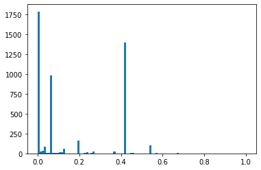

```python
plt.hist(chistats_df['pValue'], bins=np.linspace(0,1, 100))
#plt.xlim(0,0.4)
plt.show()
```

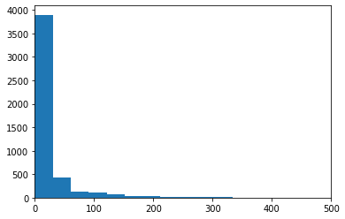

```python
plt.hist(chistats_df['Chi2'], bins=np.linspace(0,3000, 100))
plt.xlim(0,500)
plt.show()
```

```python
nltk_vocab = chistats_df.index.values
```

#### SpaCy

```python
doc = 'document_spacy_2'
cat = 'category_level1'
```

```python
counter_df = create_observation_matrix(text_df, doc, cat)
indep_df = create_expected_observation_matrix(counter_df)
create_chisquared_measure_matrix(counter_df, indep_df)
```

| category_level1 | specification | sathiyas | cotton | bath | towel | red | yellow | blue | feature | machine | ... | rana | bw | prsmd | barbie | firstrace | cb | timex | ti | hands | TOTAL |
| --- | --- | --- | --- | --- | --- | --- | --- | --- | --- | --- | --- | --- | --- | --- | --- | --- | --- | --- | --- | --- | --- |
| Baby Care | 15.571961 | 13.360383 | 433.504770 | 7.381126 | 16.711081 | 0.656146 | 18.795700 | 56.902174 | 0.048813 | 53.063498 | ... | 0.317733 | 0.476599 | 0.476599 | 0.317733 | 0.317733 | 0.317733 | 0.317733 | 0.476599 | 0.317733 | 20400.883420 |
| Beauty and Personal Care | 0.268858 | 0.348237 | 34.707600 | 0.961799 | 10.563183 | 0.187049 | 6.152183 | 7.078115 | 10.098867 | 3.526910 | ... | 0.232158 | 0.348237 | 0.348237 | 0.232158 | 0.232158 | 0.232158 | 0.232158 | 0.348237 | 0.232158 | 19425.152121 |
| Computers | 1.127696 | 0.498441 | 49.677973 | 9.304236 | 15.119383 | 0.273574 | 0.004283 | 17.987805 | 0.448161 | 7.642765 | ... | 0.332294 | 0.498441 | 0.498441 | 0.332294 | 0.332294 | 0.332294 | 0.332294 | 0.498441 | 0.332294 | 23428.051389 |
| Home Decor & Festive Needs | 12.410335 | 0.490881 | 39.435423 | 4.145304 | 14.890044 | 0.589743 | 2.159729 | 0.673017 | 2.731328 | 7.526836 | ... | 0.327254 | 0.490881 | 0.490881 | 0.327254 | 0.327254 | 0.327254 | 0.327254 | 0.490881 | 0.327254 | 17995.357520 |
| Home Furnishing | 7.693726 | 0.355069 | 129.174565 | 97.124942 | 234.253168 | 0.234345 | 2.214503 | 4.280624 | 5.171051 | 28.955122 | ... | 0.236713 | 0.355069 | 0.355069 | 0.236713 | 0.236713 | 0.236713 | 0.236713 | 0.355069 | 0.236713 | 16671.710765 |
| Kitchen & Dining | 19.907948 | 0.524931 | 52.318162 | 9.798719 | 15.922919 | 0.534395 | 9.273788 | 3.855295 | 54.398907 | 8.048948 | ... | 0.349954 | 0.524931 | 0.524931 | 0.349954 | 0.349954 | 0.349954 | 0.349954 | 0.524931 | 0.349954 | 23182.917032 |
| Watches | 6.337303 | 0.305841 | 30.482181 | 5.709037 | 9.277186 | 0.428804 | 5.403196 | 0.048006 | 5.320386 | 4.689566 | ... | 15.821913 | 23.732869 | 23.732869 | 15.821913 | 15.821913 | 15.821913 | 15.821913 | 23.732869 | 15.821913 | 24913.696681 |
| TOTAL | 63.317827 | 15.883784 | 769.300676 | 134.425164 | 316.736964 | 2.904056 | 44.003382 | 90.825036 | 78.217513 | 113.453645 | ... | 17.618019 | 26.427028 | 26.427028 | 17.618019 | 17.618019 | 17.618019 | 17.618019 | 26.427028 | 17.618019 | 146017.768928 |

8 rows × 4606 columns

```python
docfreq_df = create_documentfrequency_matrix(text_df, doc, cat)
docfreq_df.loc['TOTAL',:].T.sort_values(ascending=False)[:40]
```

```
TOTAL             33416.0
free                595.0
buy                 578.0
products            569.0
delivery            566.0
shipping            564.0
cash                564.0
genuine             564.0
price               525.0
day                 514.0
replacement         489.0
guarantee           471.0
flipkart            392.0
online              389.0
com                 385.0
general             284.0
rs                  253.0
box                 251.0
features            236.0
type                235.0
good                224.0
color               223.0
number              218.0
package             218.0
sales               217.0
pack                209.0
brand               208.0
material            206.0
key                 202.0
cm                  190.0
specifications      189.0
design              177.0
great               166.0
set                 163.0
india               162.0
specification       158.0
watch               153.0
model               149.0
ideal               144.0
contents            142.0
Name: TOTAL, dtype: float64
```

```python
chi2_values = chisquare(counter_df.iloc[:-1,:-1])
chistats_df = pd.DataFrame(np.array([chi2_values.statistic, chi2_values.pvalue]).T,
                           columns=['Chi2', 'pValue'], index=counter_df.columns[:-1]).join(counter_df.iloc[-1,:].T)
chistats_df.sort_values(by='pValue').iloc[800:860,:]
```

|  | Chi2 | pValue | TOTAL |
| --- | --- | --- | --- |
| intellect | 36.000000 | 0.000003 | 13.0 |
| blush | 36.000000 | 0.000003 | 6.0 |
| balm | 36.000000 | 0.000003 | 6.0 |
| bootie | 36.000000 | 0.000003 | 6.0 |
| frenemy | 36.000000 | 0.000003 | 6.0 |
| eurospa | 36.000000 | 0.000003 | 6.0 |
| medium | 36.000000 | 0.000003 | 27.0 |
| anna | 36.000000 | 0.000003 | 6.0 |
| dungaree | 36.000000 | 0.000003 | 6.0 |
| cater | 36.000000 | 0.000003 | 6.0 |
| fennel | 36.000000 | 0.000003 | 6.0 |
| andre | 36.000000 | 0.000003 | 6.0 |
| jumpsuit | 36.000000 | 0.000003 | 6.0 |
| beat | 36.000000 | 0.000003 | 6.0 |
| pure | 35.909091 | 0.000003 | 22.0 |
| rajasthan | 35.909091 | 0.000003 | 22.0 |
| hz | 35.750000 | 0.000003 | 8.0 |
| bathing | 35.750000 | 0.000003 | 8.0 |
| wallpaper | 35.750000 | 0.000003 | 8.0 |
| lining | 35.750000 | 0.000003 | 8.0 |
| up | 35.750000 | 0.000003 | 8.0 |
| laser | 35.750000 | 0.000003 | 8.0 |
| pane | 35.750000 | 0.000003 | 8.0 |
| gorgeous | 35.750000 | 0.000003 | 8.0 |
| assorted | 35.750000 | 0.000003 | 8.0 |
| fiber | 35.750000 | 0.000003 | 8.0 |
| stick | 35.666667 | 0.000003 | 18.0 |
| carve | 35.454545 | 0.000004 | 11.0 |
| food | 35.454545 | 0.000004 | 11.0 |
| conform | 35.454545 | 0.000004 | 11.0 |
| smooth | 35.333333 | 0.000004 | 21.0 |
| royal | 35.272727 | 0.000004 | 22.0 |
| wild | 35.000000 | 0.000004 | 14.0 |
| picture | 35.000000 | 0.000004 | 28.0 |
| use | 34.982759 | 0.000004 | 116.0 |
| exquisite | 34.923077 | 0.000004 | 13.0 |
| pa | 34.666667 | 0.000005 | 12.0 |
| silver | 34.482759 | 0.000005 | 29.0 |
| drawer | 34.470588 | 0.000005 | 17.0 |
| range | 34.250000 | 0.000006 | 48.0 |
| deliver | 33.846154 | 0.000007 | 13.0 |
| color | 33.741379 | 0.000008 | 348.0 |
| display | 33.500000 | 0.000008 | 28.0 |
| ac | 33.407407 | 0.000009 | 27.0 |
| green | 33.081081 | 0.000010 | 74.0 |
| weight | 33.058824 | 0.000010 | 102.0 |
| control | 33.000000 | 0.000010 | 14.0 |
| polo | 32.909091 | 0.000011 | 11.0 |
| limit | 32.909091 | 0.000011 | 11.0 |
| appearance | 32.909091 | 0.000011 | 11.0 |
| handicraft | 32.909091 | 0.000011 | 11.0 |
| adorn | 32.909091 | 0.000011 | 11.0 |
| desk | 32.909091 | 0.000011 | 11.0 |
| rubber | 32.222222 | 0.000015 | 9.0 |
| board | 32.222222 | 0.000015 | 9.0 |
| craftsman | 32.222222 | 0.000015 | 9.0 |
| sharp | 32.222222 | 0.000015 | 9.0 |
| stock | 32.222222 | 0.000015 | 9.0 |
| separately | 32.222222 | 0.000015 | 9.0 |
| heat | 32.000000 | 0.000016 | 14.0 |

```python
chistats_df.sort_values(by='TOTAL', ascending = False).iloc[:60,:]
```

|  | Chi2 | pValue | TOTAL |
| --- | --- | --- | --- |
| free | 69.019417 | 6.495797e-13 | 618.0 |
| buy | 72.370497 | 1.333434e-13 | 583.0 |
| products | 77.348354 | 1.259738e-14 | 577.0 |
| delivery | 81.925926 | 1.428763e-15 | 567.0 |
| genuine | 81.414894 | 1.822331e-15 | 564.0 |
| shipping | 81.414894 | 1.822331e-15 | 564.0 |
| cash | 81.414894 | 1.822331e-15 | 564.0 |
| replacement | 299.270125 | 1.172625e-61 | 559.0 |
| cm | 951.616487 | 2.598751e-202 | 558.0 |
| day | 150.101266 | 7.365038e-30 | 553.0 |
| price | 190.710866 | 1.796515e-38 | 543.0 |
| flipkart | 329.850312 | 3.256305e-68 | 481.0 |
| com | 332.029598 | 1.109646e-68 | 473.0 |
| guarantee | 211.209302 | 7.781141e-43 | 473.0 |
| mug | 2416.543689 | 0.000000e+00 | 412.0 |
| online | 217.065657 | 4.394266e-44 | 396.0 |
| design | 302.044444 | 2.983219e-62 | 360.0 |
| color | 33.741379 | 7.546802e-06 | 348.0 |
| watch | 1981.139535 | 0.000000e+00 | 344.0 |
| pack | 150.432927 | 6.266822e-30 | 328.0 |
| features | 53.663551 | 8.624224e-10 | 321.0 |
| baby | 1870.479751 | 0.000000e+00 | 321.0 |
| set | 168.420382 | 9.727284e-34 | 314.0 |
| material | 184.805112 | 3.234574e-37 | 313.0 |
| type | 55.455128 | 3.751159e-10 | 312.0 |
| cotton | 804.026756 | 2.076921e-170 | 299.0 |
| box | 53.212121 | 1.063367e-09 | 297.0 |
| general | 105.263889 | 1.996204e-20 | 288.0 |
| product | 97.317073 | 9.099132e-19 | 287.0 |
| package | 143.522059 | 1.808967e-28 | 272.0 |
| analog | 1489.923664 | 0.000000e+00 | 262.0 |
| number | 100.629921 | 1.854015e-19 | 254.0 |
| good | 184.685039 | 3.430300e-37 | 254.0 |
| rs | 148.822134 | 1.372779e-29 | 253.0 |
| warranty | 515.067729 | 4.769525e-108 | 251.0 |
| sales | 125.483871 | 1.146703e-24 | 248.0 |
| quality | 193.600000 | 4.365030e-39 | 245.0 |
| brand | 55.050000 | 4.528967e-10 | 240.0 |
| inch | 175.881857 | 2.540787e-35 | 237.0 |
| key | 70.850877 | 2.735485e-13 | 228.0 |
| model | 74.752212 | 4.316681e-14 | 226.0 |
| laptop | 1350.000000 | 1.622143e-288 | 225.0 |
| ceramic | 1140.757991 | 3.164970e-243 | 219.0 |
| fabric | 725.772512 | 1.664969e-153 | 211.0 |
| gift | 481.320574 | 8.870607e-101 | 209.0 |
| showpiece | 1200.608696 | 3.534225e-256 | 207.0 |
| size | 76.000000 | 2.388880e-14 | 203.0 |
| specifications | 51.274611 | 2.608686e-09 | 193.0 |
| great | 509.333333 | 8.203455e-107 | 189.0 |
| details | 923.703704 | 2.819326e-196 | 189.0 |
| girl | 906.677419 | 1.352794e-192 | 186.0 |
| specification | 93.698925 | 5.157637e-18 | 186.0 |
| perfect | 606.756757 | 8.132922e-128 | 185.0 |
| india | 535.866667 | 1.571437e-112 | 180.0 |
| cover | 295.162011 | 8.898154e-61 | 179.0 |
| print | 127.386364 | 4.562400e-25 | 176.0 |
| skin | 296.240000 | 5.228326e-61 | 175.0 |
| usb | 1044.000000 | 2.718037e-222 | 174.0 |
| home | 190.376471 | 2.116097e-38 | 170.0 |
| ideal | 290.682635 | 8.105729e-60 | 167.0 |

```python
chistats_df.sort_values(by='pValue', ascending = False).iloc[:60,:]
```

|  | Chi2 | pValue | TOTAL |
| --- | --- | --- | --- |
| touch | 2.352941 | 0.884549 | 17.0 |
| entire | 4.000000 | 0.676676 | 3.0 |
| functional | 4.000000 | 0.676676 | 3.0 |
| foldable | 4.000000 | 0.676676 | 3.0 |
| lot | 4.000000 | 0.676676 | 3.0 |
| monitor | 4.000000 | 0.676676 | 7.0 |
| match | 4.000000 | 0.676676 | 3.0 |
| hold | 4.250000 | 0.642885 | 8.0 |
| rich | 4.333333 | 0.631665 | 12.0 |
| perfection | 4.800000 | 0.569709 | 5.0 |
| process | 4.800000 | 0.569709 | 5.0 |
| convenience | 4.800000 | 0.569709 | 5.0 |
| attention | 4.800000 | 0.569709 | 5.0 |
| hole | 4.800000 | 0.569709 | 5.0 |
| broad | 5.000000 | 0.543813 | 2.0 |
| push | 5.000000 | 0.543813 | 2.0 |
| coverage | 5.000000 | 0.543813 | 2.0 |
| sunlight | 5.000000 | 0.543813 | 2.0 |
| cardboard | 5.000000 | 0.543813 | 2.0 |
| step | 5.000000 | 0.543813 | 2.0 |
| sj | 5.000000 | 0.543813 | 2.0 |
| inches | 5.000000 | 0.543813 | 2.0 |
| tumblers | 5.000000 | 0.543813 | 2.0 |
| manageable | 5.000000 | 0.543813 | 2.0 |
| accident | 5.000000 | 0.543813 | 2.0 |
| access | 5.000000 | 0.543813 | 2.0 |
| zero | 5.000000 | 0.543813 | 2.0 |
| nights | 5.000000 | 0.543813 | 2.0 |
| write | 5.000000 | 0.543813 | 2.0 |
| waranty | 5.000000 | 0.543813 | 2.0 |
| refresh | 5.000000 | 0.543813 | 2.0 |
| empower | 5.000000 | 0.543813 | 2.0 |
| exposure | 5.000000 | 0.543813 | 2.0 |
| ve | 5.000000 | 0.543813 | 2.0 |
| uber | 5.000000 | 0.543813 | 2.0 |
| wave | 5.000000 | 0.543813 | 2.0 |
| leak | 5.000000 | 0.543813 | 2.0 |
| retention | 5.000000 | 0.543813 | 2.0 |
| integrated | 5.000000 | 0.543813 | 2.0 |
| filter | 5.000000 | 0.543813 | 2.0 |
| lady | 5.000000 | 0.543813 | 2.0 |
| blk | 5.000000 | 0.543813 | 2.0 |
| passion | 5.000000 | 0.543813 | 2.0 |
| locking | 5.000000 | 0.543813 | 2.0 |
| poly | 5.000000 | 0.543813 | 2.0 |
| years | 5.000000 | 0.543813 | 2.0 |
| zipper | 5.000000 | 0.543813 | 2.0 |
| smoke | 5.000000 | 0.543813 | 2.0 |
| field | 5.000000 | 0.543813 | 2.0 |
| mountable | 5.000000 | 0.543813 | 2.0 |
| padding | 5.000000 | 0.543813 | 2.0 |
| artisans | 5.000000 | 0.543813 | 2.0 |
| shaped | 5.000000 | 0.543813 | 2.0 |
| team | 5.000000 | 0.543813 | 2.0 |
| accidental | 5.000000 | 0.543813 | 2.0 |
| understanding | 5.000000 | 0.543813 | 2.0 |
| cross | 5.000000 | 0.543813 | 2.0 |
| concept | 5.000000 | 0.543813 | 2.0 |
| regulate | 5.000000 | 0.543813 | 2.0 |
| navy | 5.000000 | 0.543813 | 2.0 |

```python
word = 'perfect'
counter_df[word].append(chistats_df.loc[word, ['Chi2', 'pValue']])
```

```
Baby Care                      5.000000e+00
Beauty and Personal Care       4.000000e+00
Computers                      1.100000e+01
Home Decor & Festive Needs     1.700000e+01
Home Furnishing                5.000000e+00
Kitchen & Dining               1.430000e+02
Watches                        0.000000e+00
TOTAL                          1.850000e+02
Chi2                           6.067568e+02
pValue                        8.132922e-128
Name: perfect, dtype: float64
```

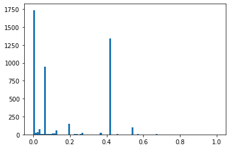

```python
plt.hist(chistats_df['pValue'], bins=np.linspace(0,1, 100))
#plt.xlim(0,0.4)
plt.show()
```

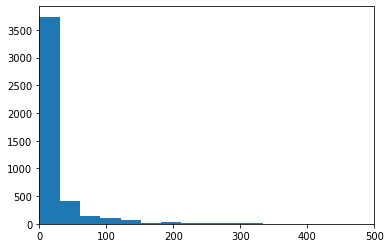

```python
plt.hist(chistats_df['Chi2'], bins=np.linspace(0,3000, 100))
plt.xlim(0,500)
plt.show()
```

```python
spacy_vocab = chistats_df.index.values
```

### 3.5.3 Comparison du Vocabulaire NLTK et SpaCy - 2

```python
set(nltk_vocab)-set(spacy_vocab)
```

```
{'abstracts',
 'abstrcts',
 'according',
 'across',
 'added',
 'adds',
 'admired',
 'adorning',
 'aiding',
 'allowing',
 'allows',
 'allure',
 'almost',
 'along',
 'also',
 'although',
 'always',
 'among',
 'amongst',
 'amount',
 'amplifying',
 'annoy',
 'another',
 'anyone',
 'anything',
 'anywhere',
 'applied',
 'applies',
 'around',
 'asked',
 'assembled',
 'awakened',
 'beaded',
 'beads',
 'beautifying',
 'become',
 'becomes',
 'behind',
 'benefits',
 'besides',
```

[output cut: 258 more lines]

```
 'watercolors',
 'wed',
 'welcomed',
 'wheeled',
 'whereas',
 'wherever',
 'whether',
 'whole',
 'winters',
 'within',
 'without',
 'would',
 'wrapped',
 'yet',
 'yr'}
```

```python
set(spacy_vocab)-set(nltk_vocab)
```

```
{'abstrct',
 'aching',
 'aging',
 'alluring',
 'annoying',
 'anodise',
 'appealing',
 'ask',
 'bead',
 'casing',
 'checker',
 'clothe',
 'colds',
 'compaingn',
 'comprise',
 'curate',
 'customize',
 'datum',
 'deodorizing',
 'derive',
 'desire',
 'don',
 'drill',
 'echo',
 'elasticate',
 'electrode',
 'eliminate',
 'embody',
 'enchanting',
 'ensconce',
 'establish',
 'expose',
 'fascinating',
 'feeling',
 'fields',
 'fix',
 'flavoring',
 'flawer',
 'formulate',
 'furnish',
```

[output cut: 64 more lines]

```
 'tatvaart',
 'temper',
 'thank',
 'tiedribbon',
 'tooth',
 'toy',
 'trust',
 'unlock',
 'up',
 've',
 'walk',
 'watercolor',
 'wouldn',
 'you',
 'yrs'}
```

## 3.6 WordClouds

```python
# import the wordcloud library
from wordcloud import WordCloud
# Instantiate a new wordcloud.
wordcloud = WordCloud(random_state = 8,
            normalize_plurals = True,
            background_color = None,
            colormap = 'gist_heat',
            #stopwords=[],
            mode = 'RGBA',
            contour_width = 5,
            collocations = False,
            min_font_size = 40,
            #max_font_size = 200,
            width = 1200, height = 800)
```

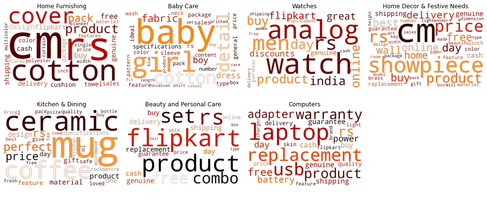

```python
cat = 'category_level1'

fig, axes = plt.subplots(2,4, figsize = (14,6))
for i, cl in enumerate(text_df[cat].unique()):
    # Apply the wordcloud to the text.
    select = (text_df[cat] == cl)
    wordcloud.generate(' '.join(text_df['description'][select].str.lower()))
    # add interpolation = bilinear to smooth things out
    #print(i%2, i//2)
    ax = axes[i//4][i%4]
    ax.imshow(wordcloud, interpolation='bilinear')
    # and remove the axis
    ax.set_title(cl)
    ax.axis("off")
ax = axes[1][3]
ax.axis("off")
plt.tight_layout()
```

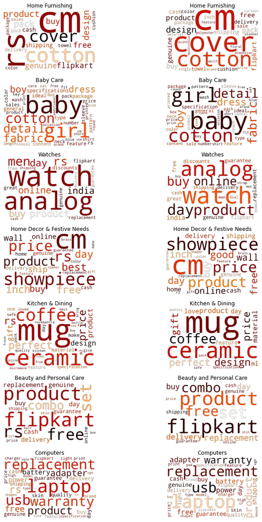

```python
cat = 'category_level1'

fig, axes = plt.subplots(7,2, figsize = (12,21))
for i, cl in enumerate(text_df[cat].unique()):
    # Apply the wordcloud to the text.
    select = (text_df[cat] == cl)
    for j, tok_ver in enumerate(['nltk_2','spacy_2']):
        wordcloud.generate(' '.join(text_df['document_'+tok_ver][select]))
        # add interpolation = bilinear to smooth things out
        ax = axes[i][j]
        ax.imshow(wordcloud, interpolation='bilinear')
        # and remove the axis
        ax.set_title(cl)
        ax.axis("off")
```

```python
stopwords = ['product', 'products', 'replacement', 'guarantee', 'one','day', 'free', 'shipping', 'genuine', 'price', 'prices',
             'cash', 'delivery','rs', 'package', 'contents', 'content', 'sales', 'sale', 'details', 'detail',
             'flipkart', 'com', 'online', 'buy', 'discount', 'discounts', 'general', 'specification', 'specifications',
             'pack', 'packs', 'good','great', 'best', 'type', 'types', 'model','number', 'numbers', 'feature', 'features',
             'material', 'materials', 'brand', 'perfect', 'ideal', 'box', 'high', 'quality', 'quantity','exclusive',
             'color', 'colour', 'size', 'sizes', 'dimension', 'dimensions', 'style', 'styles', 'design', 'beautiful']
```

```python
wordcloud = WordCloud(random_state = 8,
                      normalize_plurals = False,
                      width = 1200, height= 600,
                      stopwords=stopwords)
```

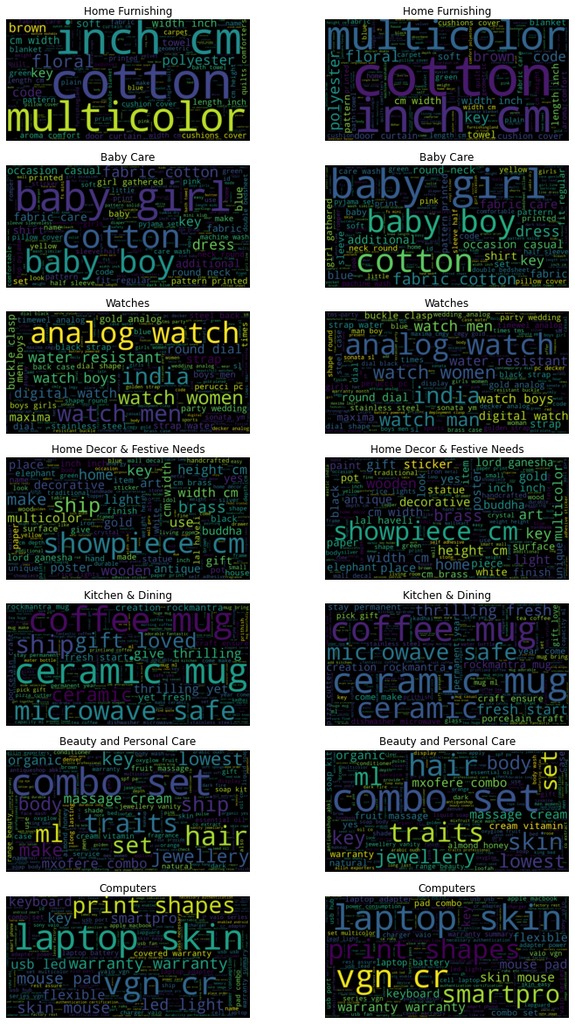

```python
cat = 'category_level1'

fig, axes = plt.subplots(7,2, figsize = (12,21))
for i, cl in enumerate(text_df[cat].unique()):
    # Apply the wordcloud to the text.
    select = (text_df[cat] == cl)
    for j, tok_ver in enumerate(['nltk_2','spacy_2']):
        txt = ' '.join(text_df['document_'+tok_ver][select])
        wordcloud.generate(txt)
        # add interpolation = bilinear to smooth things out
        ax = axes[i][j]
        ax.imshow(wordcloud, interpolation='bilinear')
        # and remove the axis
        ax.set_title(cl)
        ax.axis("off")
```

## 3.7 Réduction du Vocabulaire

```python
text_df['document_nltk_2']
```

```
0       key features elegance polyester multicolor abs...
1       specifications sathiyas cotton bath towel bath...
2       key features eurospa cotton terry face towel s...
3       key features santosh royal fashion cotton prin...
4       key features jaipur print cotton floral king s...
                              ...
1045    oren empower extra large self adhesive sticker...
1046    wallmantra large vinyl sticker sticker pack pr...
1047    buy uberlyfe extra large pigmented polyvinyl f...
1048    buy wallmantra medium vinyl sticker sticker rs...
1049    buy uberlyfe large vinyl sticker rs online ube...
Name: document_nltk_2, Length: 1050, dtype: object
```

```python
for tok_ver in ['nltk','spacy']:
    text_df['document_'+tok_ver+'_3']=drop_stopwords(text_df['document_'+tok_ver+'_2'], stopwords)
```

### 3.7.1 Fréquence des Tokens dans le Corpus

#### NLTK et WordNet

```python
doc = 'document_nltk_3'
```

```
(0.5, 20.5)
```

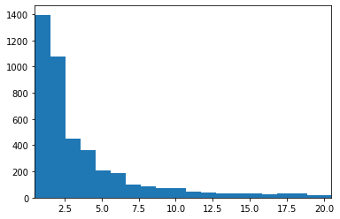

```python
plt.hist([n for t, n in token_counter(text_df[doc]).items()], bins=np.linspace(0.5,50.5))
plt.xlim(0.5,20.5)
```

```python
sorted(token_counter(text_df[doc]).items(), key=lambda x:x[1], reverse=True)
```

```
[('cm', 594),
 ('mug', 406),
 ('watch', 336),
 ('baby', 321),
 ('set', 314),
 ('cotton', 299),
 ('make', 272),
 ('analog', 262),
 ('warranty', 252),
 ('inch', 237),
 ('key', 227),
 ('laptop', 224),
 ('ceramic', 219),
 ('fabric', 211),
 ('showpiece', 207),
 ('use', 190),
 ('ship', 188),
 ('gift', 186),
 ('india', 180),
 ('men', 177),
 ('skin', 175),
 ('usb', 174),
 ('home', 170),
 ('print', 170),
 ('girl', 168),
 ('coffee', 164),
 ('multicolor', 160),
 ('cover', 152),
 ('combo', 149),
 ('water', 146),
 ('women', 137),
 ('black', 133),
 ('ml', 133),
 ('width', 132),
 ('adapter', 131),
 ('wash', 129),
 ('light', 127),
 ('also', 127),
 ('give', 126),
 ('power', 123),
```

[output cut: 946 more lines]

```
 ('handi', 7),
 ('professional', 7),
 ('pottery', 7),
 ('ice', 7),
 ('superior', 7),
 ('primary', 7),
 ('vase', 7),
 ('awesome', 7),
 ('another', 7),
 ('stickers', 7),
 ('effort', 7),
 ('sound', 7),
 ('processor', 7),
 ('angel', 7),
 ...]
```

```python
print("Average Number of Counts per Token:",
      np.array([n for t, n in token_counter(text_df[doc]).items()]).mean())
print("Average Number of Tokens per Document:",
      np.array([len(txt.split()) for txt in text_df[doc]]).mean())
print("Total Number of Unique Tokens:", len(list(token_counter(text_df[doc]))))
```

```
Average Number of Counts per Token: 8.575195106517612
Average Number of Tokens per Document: 38.71904761904762
Total Number of Unique Tokens: 4741
```

#### SpaCy

```python
doc = 'document_spacy_3'
```

```
(0.5, 20.5)
```

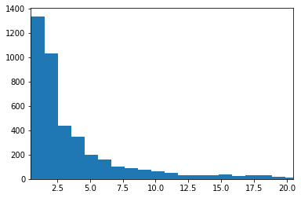

```python
plt.hist([n for t, n in token_counter(text_df[doc]).items()], bins=np.linspace(0.5,50.5))
plt.xlim(0.5,20.5)
```

```python
print("Average Number of Counts per Token:",
      np.array([n for t, n in token_counter(text_df[doc]).items()]).mean())
print("Average Number of Tokens per Document:",
      np.array([len(txt.split()) for txt in text_df[doc]]).mean())
print("Total Number of Unique Tokens:", len(list(token_counter(text_df[doc]))))
```

```
Average Number of Counts per Token: 8.512752858399296
Average Number of Tokens per Document: 36.87238095238095
Total Number of Unique Tokens: 4548
```

### 3.7.2 Chi2 et le pValues des Tokens

#### NLTK et Wordnet

```python
doc = 'document_nltk_3'
cat = 'category_level1'
```

```python
counter_df = create_observation_matrix(text_df, doc, cat)
```

```python
counter_df.loc['TOTAL',:].T.sort_values(ascending=False)[:60]
```

```
TOTAL         40655.0
cm              594.0
mug             406.0
watch           336.0
baby            321.0
set             314.0
cotton          299.0
make            272.0
analog          262.0
warranty        252.0
inch            237.0
key             227.0
laptop          224.0
ceramic         219.0
fabric          211.0
showpiece       207.0
use             190.0
ship            188.0
gift            186.0
india           180.0
men             177.0
skin            175.0
usb             174.0
print           170.0
home            170.0
girl            168.0
coffee          164.0
multicolor      160.0
cover           152.0
combo           149.0
water           146.0
women           137.0
ml              133.0
black           133.0
width           132.0
adapter         131.0
wash            129.0
also            127.0
light           127.0
give            126.0
power           123.0
care            121.0
blue            120.0
battery         119.0
pattern         119.0
height          115.0
yes             115.0
length          109.0
printed         109.0
look            108.0
easy            108.0
name            105.0
dress           105.0
round           104.0
wall            103.0
weight          102.0
body            101.0
come            100.0
boy              93.0
casual           92.0
Name: TOTAL, dtype: float64
```

```python
indep_df = create_expected_observation_matrix(counter_df)
create_chisquared_measure_matrix(counter_df, indep_df)
```

| category_level1 | sathiyas | cotton | bath | towel | red | yellow | blue | machine | washable | yes | ... | rana | bw | prsmd | barbie | firstrace | cb | timex | ti | hands | TOTAL |
| --- | --- | --- | --- | --- | --- | --- | --- | --- | --- | --- | --- | --- | --- | --- | --- | --- | --- | --- | --- | --- | --- |
| Baby Care | 12.494406 | 399.675457 | 5.914366 | 15.492839 | 0.395203 | 16.744727 | 51.163177 | 48.725679 | 3.783988 | 0.035689 | ... | 0.333440 | 0.500160 | 0.500160 | 0.333440 | 0.333440 | 0.333440 | 0.333440 | 0.500160 | 0.333440 | 18233.062218 |
| Beauty and Personal Care | 0.314943 | 31.389300 | 0.161781 | 9.343303 | 0.027610 | 5.563990 | 5.867784 | 3.036200 | 0.914083 | 3.974717 | ... | 0.209962 | 0.314943 | 0.314943 | 0.209962 | 0.209962 | 0.209962 | 0.209962 | 0.314943 | 0.209962 | 20530.862553 |
| Computers | 0.518313 | 51.658492 | 9.847940 | 15.376608 | 0.418863 | 0.002687 | 18.780739 | 7.947460 | 4.548955 | 8.334847 | ... | 0.345542 | 0.518313 | 0.518313 | 0.345542 | 0.345542 | 0.345542 | 0.345542 | 0.518313 | 0.345542 | 22512.754148 |
| Home Decor & Festive Needs | 0.515140 | 41.829174 | 4.707178 | 15.282474 | 0.835536 | 1.670597 | 1.029401 | 7.898807 | 1.769955 | 2.663985 | ... | 0.343426 | 0.515140 | 0.515140 | 0.343426 | 0.343426 | 0.343426 | 0.343426 | 0.515140 | 0.343426 | 17049.483551 |
| Home Furnishing | 0.344459 | 137.350979 | 99.006493 | 232.860134 | 0.162849 | 2.518087 | 4.905878 | 30.625458 | 58.402899 | 0.777582 | ... | 0.229640 | 0.344459 | 0.344459 | 0.229640 | 0.229640 | 0.229640 | 0.229640 | 0.344459 | 0.229640 | 16747.268894 |
| Kitchen & Dining | 0.560669 | 55.880015 | 10.652712 | 16.633182 | 0.225770 | 9.905153 | 4.847662 | 8.596925 | 6.914918 | 4.205974 | ... | 0.373779 | 0.560669 | 0.560669 | 0.373779 | 0.373779 | 0.373779 | 0.373779 | 0.560669 | 0.373779 | 21078.984284 |
| Watches | 0.246317 | 24.549551 | 4.680015 | 7.307391 | 1.724356 | 4.351593 | 1.005386 | 3.776854 | 3.037904 | 7.548043 | ... | 20.523109 | 30.784663 | 30.784663 | 20.523109 | 20.523109 | 20.523109 | 20.523109 | 30.784663 | 20.523109 | 26600.153470 |
| TOTAL | 14.994246 | 742.332969 | 134.970485 | 312.295931 | 3.790187 | 40.756834 | 87.600027 | 110.607384 | 79.372703 | 27.540838 | ... | 22.358898 | 33.538346 | 33.538346 | 22.358898 | 22.358898 | 22.358898 | 22.358898 | 33.538346 | 22.358898 | 142752.569117 |

8 rows × 4742 columns

```python
chi2_values = chisquare(counter_df.iloc[:-1,:-1])
chistats_df = pd.DataFrame(np.array([chi2_values.statistic, chi2_values.pvalue]).T,
                           columns=['Chi2', 'pValue'], index=counter_df.columns[:-1]).join(counter_df.iloc[-1,:].T)
chistats_df.sort_values(by='pValue').iloc[:40,:]
```

|  | Chi2 | pValue | TOTAL |
| --- | --- | --- | --- |
| watch | 1933.166667 | 0.000000e+00 | 336.0 |
| baby | 1870.479751 | 0.000000e+00 | 321.0 |
| mug | 2380.551724 | 0.000000e+00 | 406.0 |
| analog | 1489.923664 | 0.000000e+00 | 262.0 |
| laptop | 1344.000000 | 3.229306e-287 | 224.0 |
| showpiece | 1200.608696 | 3.534225e-256 | 207.0 |
| ceramic | 1140.757991 | 3.164970e-243 | 219.0 |
| usb | 1044.000000 | 2.718037e-222 | 174.0 |
| girl | 980.333333 | 1.602327e-208 | 168.0 |
| cm | 963.087542 | 8.594938e-205 | 594.0 |
| coffee | 942.597561 | 2.317106e-200 | 164.0 |
| men | 820.598870 | 5.451402e-174 | 177.0 |
| cotton | 804.026756 | 2.076921e-170 | 299.0 |
| adapter | 786.000000 | 1.630174e-166 | 131.0 |
| fabric | 725.772512 | 1.664969e-153 | 211.0 |
| dress | 630.000000 | 7.862972e-133 | 105.0 |
| battery | 546.000000 | 1.028214e-114 | 119.0 |
| boy | 544.150538 | 2.574854e-114 | 93.0 |
| india | 535.866667 | 1.571437e-112 | 180.0 |
| dial | 532.153846 | 9.919947e-112 | 91.0 |
| warranty | 519.944444 | 4.242906e-109 | 252.0 |
| women | 514.306569 | 6.957918e-108 | 137.0 |
| power | 509.560976 | 7.327427e-107 | 123.0 |
| sleeve | 480.000000 | 1.707402e-100 | 80.0 |
| neck | 472.172840 | 8.274881e-99 | 81.0 |
| gift | 443.698925 | 1.114306e-92 | 186.0 |
| ml | 440.947368 | 4.356309e-92 | 133.0 |
| combo | 436.134228 | 4.729215e-91 | 149.0 |
| safe | 415.692308 | 1.180851e-86 | 91.0 |
| strap | 400.466667 | 2.218957e-83 | 90.0 |
| loved | 395.272727 | 2.902127e-82 | 77.0 |
| rockmantra | 390.000000 | 3.945204e-81 | 65.0 |
| charger | 372.000000 | 2.909993e-77 | 62.0 |
| shirt | 372.000000 | 2.909993e-77 | 62.0 |
| wall | 343.708738 | 3.458925e-71 | 103.0 |
| microwave | 342.000000 | 8.047948e-71 | 57.0 |
| cover | 325.842105 | 2.357987e-67 | 152.0 |
| cr | 324.000000 | 5.856734e-67 | 54.0 |
| pizza | 324.000000 | 5.856734e-67 | 54.0 |
| vgn | 318.000000 | 1.133455e-65 | 53.0 |

```python
chistats_df.sort_values(by='pValue', ascending = False).iloc[:40,:]
```

|  | Chi2 | pValue | TOTAL |
| --- | --- | --- | --- |
| touch | 2.352941 | 0.884549 | 17.0 |
| gives | 4.000000 | 0.676676 | 3.0 |
| field | 4.000000 | 0.676676 | 3.0 |
| least | 4.000000 | 0.676676 | 3.0 |
| entire | 4.000000 | 0.676676 | 3.0 |
| monitor | 4.000000 | 0.676676 | 7.0 |
| functional | 4.000000 | 0.676676 | 3.0 |
| months | 4.000000 | 0.676676 | 3.0 |
| match | 4.000000 | 0.676676 | 3.0 |
| foldable | 4.000000 | 0.676676 | 3.0 |
| see | 4.222222 | 0.646632 | 9.0 |
| last | 4.250000 | 0.642885 | 8.0 |
| rich | 4.333333 | 0.631665 | 12.0 |
| attention | 4.800000 | 0.569709 | 5.0 |
| hole | 4.800000 | 0.569709 | 5.0 |
| convenience | 4.800000 | 0.569709 | 5.0 |
| perfection | 4.800000 | 0.569709 | 5.0 |
| process | 4.800000 | 0.569709 | 5.0 |
| click | 5.000000 | 0.543813 | 2.0 |
| passion | 5.000000 | 0.543813 | 2.0 |
| highlight | 5.000000 | 0.543813 | 2.0 |
| empower | 5.000000 | 0.543813 | 2.0 |
| rugged | 5.000000 | 0.543813 | 2.0 |
| zero | 5.000000 | 0.543813 | 2.0 |
| sj | 5.000000 | 0.543813 | 2.0 |
| locking | 5.000000 | 0.543813 | 2.0 |
| funny | 5.000000 | 0.543813 | 2.0 |
| zipper | 5.000000 | 0.543813 | 2.0 |
| disease | 5.000000 | 0.543813 | 2.0 |
| construction | 5.000000 | 0.543813 | 2.0 |
| smoke | 5.000000 | 0.543813 | 2.0 |
| write | 5.000000 | 0.543813 | 2.0 |
| regulate | 5.000000 | 0.543813 | 2.0 |
| nights | 5.000000 | 0.543813 | 2.0 |
| entrance | 5.000000 | 0.543813 | 2.0 |
| brilliance | 5.000000 | 0.543813 | 2.0 |
| gems | 5.000000 | 0.543813 | 2.0 |
| team | 5.000000 | 0.543813 | 2.0 |
| access | 5.000000 | 0.543813 | 2.0 |
| delicate | 5.000000 | 0.543813 | 2.0 |

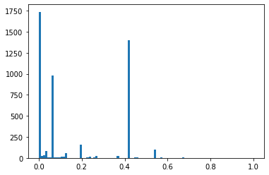

```python
plt.hist(chistats_df['pValue'], bins=np.linspace(0,1, 100))
#plt.xlim(0,0.4)
plt.show()
```

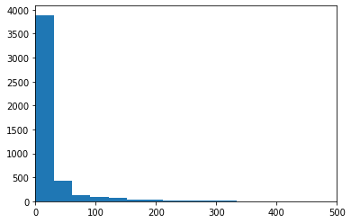

```python
plt.hist(chistats_df['Chi2'], bins=np.linspace(0,3000, 100))
plt.xlim(0,500)
plt.show()
```

```python
nltk_vocab = chistats_df.index.values
```

#### SpaCy

```python
doc = 'document_spacy_3'
cat = 'category_level1'
```

```python
counter_df = create_observation_matrix(text_df, doc, cat)
indep_df = create_expected_observation_matrix(counter_df)
create_chisquared_measure_matrix(counter_df, indep_df)
```

| category_level1 | sathiyas | cotton | bath | towel | red | yellow | blue | machine | washable | yes | ... | rana | bw | prsmd | barbie | firstrace | cb | timex | ti | hands | TOTAL |
| --- | --- | --- | --- | --- | --- | --- | --- | --- | --- | --- | --- | --- | --- | --- | --- | --- | --- | --- | --- | --- | --- |
| Baby Care | 12.343255 | 393.785365 | 6.104579 | 14.112791 | 0.355295 | 16.390433 | 50.169520 | 47.971029 | 3.668242 | 0.022528 | ... | 0.336347 | 0.504520 | 0.504520 | 0.336347 | 0.336347 | 0.336347 | 0.336347 | 0.504520 | 0.336347 | 17469.454007 |
| Beauty and Personal Care | 0.318783 | 31.772032 | 0.639413 | 9.669749 | 0.039302 | 5.631832 | 6.006090 | 3.092587 | 0.949039 | 3.761717 | ... | 0.212522 | 0.318783 | 0.318783 | 0.212522 | 0.212522 | 0.212522 | 0.212522 | 0.318783 | 0.212522 | 19987.479978 |
| Computers | 0.515523 | 51.380489 | 9.623102 | 15.637540 | 0.396957 | 0.001271 | 18.669426 | 7.904691 | 4.515400 | 8.241267 | ... | 0.343682 | 0.515523 | 0.515523 | 0.343682 | 0.343682 | 0.343682 | 0.343682 | 0.515523 | 0.343682 | 22052.840871 |
| Home Decor & Festive Needs | 0.511494 | 41.469297 | 4.490504 | 15.515317 | 0.796609 | 1.738545 | 0.972125 | 7.842907 | 1.735089 | 2.787358 | ... | 0.340996 | 0.511494 | 0.511494 | 0.340996 | 0.340996 | 0.340996 | 0.340996 | 0.511494 | 0.340996 | 16693.447641 |
| Home Furnishing | 0.349390 | 133.481225 | 99.530097 | 239.696312 | 0.194720 | 2.373287 | 4.607361 | 29.835320 | 57.134909 | 0.859720 | ... | 0.232927 | 0.349390 | 0.349390 | 0.232927 | 0.232927 | 0.232927 | 0.232927 | 0.349390 | 0.232927 | 16173.667414 |
| Kitchen & Dining | 0.545511 | 54.369253 | 10.182870 | 16.547164 | 0.338202 | 9.637359 | 4.419754 | 8.364500 | 6.727968 | 4.867373 | ... | 0.363674 | 0.545511 | 0.545511 | 0.363674 | 0.363674 | 0.363674 | 0.363674 | 0.545511 | 0.363674 | 20759.881438 |
| Watches | 0.254778 | 25.392912 | 4.755863 | 7.728278 | 1.463136 | 4.501085 | 0.774175 | 3.906602 | 3.142267 | 7.868896 | ... | 19.719731 | 29.579596 | 29.579596 | 19.719731 | 19.719731 | 19.719731 | 19.719731 | 29.579596 | 19.719731 | 25170.216201 |
| TOTAL | 14.838734 | 731.650573 | 135.326428 | 318.907151 | 3.584221 | 40.273811 | 85.618452 | 108.917637 | 77.872913 | 28.408858 | ... | 21.549878 | 32.324818 | 32.324818 | 21.549878 | 21.549878 | 21.549878 | 21.549878 | 32.324818 | 21.549878 | 138306.987549 |

8 rows × 4549 columns

```python
chi2_values = chisquare(counter_df.iloc[:-1,:-1])
chistats_df = pd.DataFrame(np.array([chi2_values.statistic, chi2_values.pvalue]).T,
                           columns=['Chi2', 'pValue'], index=counter_df.columns[:-1]).join(counter_df.iloc[-1,:].T)
chistats_df.sort_values(by='pValue').iloc[:20,:]
```

|  | Chi2 | pValue | TOTAL |
| --- | --- | --- | --- |
| baby | 1870.479751 | 0.000000e+00 | 321.0 |
| mug | 2416.543689 | 0.000000e+00 | 412.0 |
| analog | 1489.923664 | 0.000000e+00 | 262.0 |
| watch | 1981.139535 | 0.000000e+00 | 344.0 |
| laptop | 1350.000000 | 1.622143e-288 | 225.0 |
| showpiece | 1200.608696 | 3.534225e-256 | 207.0 |
| ceramic | 1140.757991 | 3.164970e-243 | 219.0 |
| usb | 1044.000000 | 2.718037e-222 | 174.0 |
| cm | 951.616487 | 2.598751e-202 | 558.0 |
| coffee | 942.597561 | 2.317106e-200 | 164.0 |
| girl | 906.677419 | 1.352794e-192 | 186.0 |
| cotton | 804.026756 | 2.076921e-170 | 299.0 |
| adapter | 786.000000 | 1.630174e-166 | 131.0 |
| fabric | 725.772512 | 1.664969e-153 | 211.0 |
| dress | 630.000000 | 7.862972e-133 | 105.0 |
| battery | 546.000000 | 1.028214e-114 | 119.0 |
| power | 544.465116 | 2.202637e-114 | 129.0 |
| india | 535.866667 | 1.571437e-112 | 180.0 |
| dial | 532.153846 | 9.919947e-112 | 91.0 |
| man | 519.920000 | 4.294679e-109 | 100.0 |

```python
chistats_df.sort_values(by='pValue', ascending = False).iloc[:20,:]
```

|  | Chi2 | pValue | TOTAL |
| --- | --- | --- | --- |
| touch | 2.352941 | 0.884549 | 17.0 |
| lot | 4.000000 | 0.676676 | 3.0 |
| monitor | 4.000000 | 0.676676 | 7.0 |
| match | 4.000000 | 0.676676 | 3.0 |
| entire | 4.000000 | 0.676676 | 3.0 |
| functional | 4.000000 | 0.676676 | 3.0 |
| foldable | 4.000000 | 0.676676 | 3.0 |
| hold | 4.250000 | 0.642885 | 8.0 |
| rich | 4.333333 | 0.631665 | 12.0 |
| attention | 4.800000 | 0.569709 | 5.0 |
| convenience | 4.800000 | 0.569709 | 5.0 |
| perfection | 4.800000 | 0.569709 | 5.0 |
| process | 4.800000 | 0.569709 | 5.0 |
| hole | 4.800000 | 0.569709 | 5.0 |
| branding | 5.000000 | 0.543813 | 2.0 |
| passion | 5.000000 | 0.543813 | 2.0 |
| turbo | 5.000000 | 0.543813 | 2.0 |
| coverage | 5.000000 | 0.543813 | 2.0 |
| exposure | 5.000000 | 0.543813 | 2.0 |
| cleanse | 5.000000 | 0.543813 | 2.0 |

```python
word = 'monitor'
counter_df[word].append(chistats_df.loc[word, ['Chi2', 'pValue']])
```

```
Baby Care                     1.000000
Beauty and Personal Care      1.000000
Computers                     2.000000
Home Decor & Festive Needs    1.000000
Home Furnishing               0.000000
Kitchen & Dining              0.000000
Watches                       2.000000
TOTAL                         7.000000
Chi2                          4.000000
pValue                        0.676676
Name: monitor, dtype: float64
```

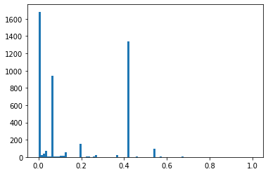

```python
plt.hist(chistats_df['pValue'], bins=np.linspace(0,1, 100))
#plt.xlim(0,0.4)
plt.show()
```

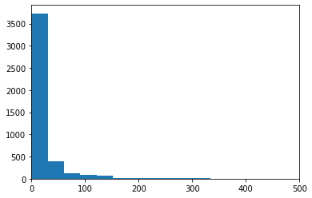

```python
plt.hist(chistats_df['Chi2'], bins=np.linspace(0,3000, 100))
plt.xlim(0,500)
plt.show()
```

```python
spacy_vocab = chistats_df.index.values
```

### 3.7.3 Comparison du Vocabulaire NLTK et SpaCy - 2

```python
set(nltk_vocab)-set(spacy_vocab)
```

```
{'abstracts',
 'abstrcts',
 'according',
 'across',
 'added',
 'adds',
 'admired',
 'adorning',
 'aiding',
 'allowing',
 'allows',
 'allure',
 'almost',
 'along',
 'also',
 'although',
 'always',
 'among',
 'amongst',
 'amount',
 'amplifying',
 'annoy',
 'another',
 'anyone',
 'anything',
 'anywhere',
 'applied',
 'applies',
 'around',
 'asked',
 'assembled',
 'awakened',
 'beaded',
 'beads',
 'beautifying',
 'become',
 'becomes',
 'behind',
 'benefits',
 'besides',
```

[output cut: 257 more lines]

```
 'watercolors',
 'wed',
 'welcomed',
 'wheeled',
 'whereas',
 'wherever',
 'whether',
 'whole',
 'winters',
 'within',
 'without',
 'would',
 'wrapped',
 'yet',
 'yr'}
```

```python
set(spacy_vocab)-set(nltk_vocab)
```

```
{'abstrct',
 'aching',
 'aging',
 'alluring',
 'annoying',
 'anodise',
 'appealing',
 'ask',
 'bead',
 'casing',
 'checker',
 'clothe',
 'colds',
 'compaingn',
 'comprise',
 'curate',
 'customize',
 'datum',
 'deodorizing',
 'derive',
 'desire',
 'don',
 'drill',
 'echo',
 'elasticate',
 'electrode',
 'eliminate',
 'embody',
 'enchanting',
 'ensconce',
 'establish',
 'expose',
 'fascinating',
 'feeling',
 'fields',
 'fix',
 'flavoring',
 'flawer',
 'formulate',
 'furnish',
```

[output cut: 64 more lines]

```
 'tatvaart',
 'temper',
 'thank',
 'tiedribbon',
 'tooth',
 'toy',
 'trust',
 'unlock',
 'up',
 've',
 'walk',
 'watercolor',
 'wouldn',
 'you',
 'yrs'}
```

### 3.7.4 Une example de Tokenisation et Lemmatisation

```
Product Name
2c8912b849cf73676d025aa99203b6d1.jpg ["Lula Baby Girl's Dark Blue Bodysuit"]

Full Description
["Key Features of Lula Baby Girl's Dark Blue Bodysuit Fabric: cotton spandex Brand Color: ROYAL BLUE,Lula Baby Girl's Dark Blue Bodysuit Price: Rs. 330 Lula babywear is designed to caress the baby like rose petals. Softest and safest cotton wear made for the comfort of the babies. Produced with fine…

Tokens with POS
['key features of lula baby girl s dark blue bodysuit fabric cotton spandex brand color royal blue lula baby girl s dark blue bodysuit price rs lula babywear is designed to caress the baby like rose petals softest and safest cotton wear made for the comfort of the babies produced with finest combed …

Lemmas
['key features lula baby girl dark blue bodysuit fabric cotton spandex brand color royal blue lula baby girl dark blue bodysuit price rs lula babywear design caress baby like rise petal softest safe cotton wear make comfort baby produced fine comb cotton material meet international standard safety s…

Doc NLTK
['key lula baby girl dark blue bodysuit fabric cotton spandex royal blue lula baby girl dark blue bodysuit lula babywear caress baby like rise petal softest safe cotton wear make comfort baby produced fine comb cotton meet international standard safety suitable delicate skin baby lula babywear gentl…

Doc Spacy
['key lula baby girl dark blue bodysuit fabric cotton spandex royal blue lula baby girl dark blue bodysuit lula babywear caress baby like rose petal softest safe cotton wear comfort baby produce fine comb cotton meet international standard safety suitable delicate skin baby lula babywear gentle hook…
```

[figure not shown]

```python
for name in random.sample(photo_list, k=1) :
    name = '2c8912b849cf73676d025aa99203b6d1.jpg'
    print("Product Name")
    print(name, text_df[text_df["image_file"]==name]["product_name"].values)
    print()
    print("Full Description")
    print(text_df[text_df["image_file"]==name]["description"].values)
    print()
    print("Tokens with POS")
    print(text_df[text_df["image_file"]==name]["tokens_with_pos_nltk_2"].apply(
          lambda x : ' '.join([l[0].lower() for l in x ])).values)
    print()
    print("Lemmas")
    print(text_df[text_df["image_file"]==name]["lemmas_nltk_2"].apply(' '.join).values)
    print()
    print("Doc NLTK")
    print(text_df[text_df["image_file"]==name]["document_nltk_3"].values)
    print()
    print("Doc Spacy")
    print(text_df[text_df["image_file"]==name]["document_spacy_3"].values)
    filename = PATH + "Images\\" + name
    image = imread(filename)
    plt.imshow(image)
plt.show()
```

## 3.8 Export du Texte Document

```python
filename = 'Text_Tokenized'
text_df.filter(['image_id', 'product_name', 'category_level1', 'category_level2',
                'document_nltk', 'document_spacy',
                'document_nltk_2', 'document_spacy_2',
                'document_nltk_3', 'document_spacy_3',]).to_csv(os.getcwd() + '\\Data\\' + filename + '.csv')
```